# CJ analysis of decision data

## Statistics 2 NZJES 2020: analysis

Number of judges =

```
## [1] 21
```

List of number of judgements per judge =

```
##  [1] 16 50 63 99 99 99 99 99 99 99 99 99 99 99 99 99 99 99 99 99 99
```

Number of scripts =

```
## [1] 119
```

List of number of judgements per script =

```
##   [1] 30 31 31 31 31 31 31 31 31 31 31 31 31 31 31 31 31 31 31 31 31 31 31 31 31
##  [26] 31 31 31 32 32 32 32 32 32 32 32 32 32 32 32 32 32 32 32 32 32 32 32 32 32
##  [51] 32 32 32 32 32 32 32 32 32 32 32 32 32 32 32 32 32 32 32 32 32 32 32 32 32
##  [76] 32 32 32 32 32 32 32 32 32 32 32 32 32 32 32 33 33 33 33 33 33 33 33 33 33
## [101] 33 33 33 33 33 33 33 33 33 33 34 34 34 34 34 35 35 35 36
```

```
## [1] 32
```

```
## [1] 1911
```

SSR=

```
## [1] 0.902
```

Count of 1s and 0s in raw, Count of 1s and 0s in raw, Correlation of theta and raw

```
## [1] 0
```

```
## [1] 1
```

```
## [1] 0.008403361
```

```
## [1] 0.970188
```

###Judge misfits

Number of misfits=

```
## [1] 0
```

Misfit threshold (2 SDs above mean) =

```
## [1] 0.7783964
```

Table of misfits (shows ‘0 rows’ if na)

```
## [1] Judge   total   average
## <0 rows> (or 0-length row.names)
```

###Script misfits

Number of misfits=

```
## [1] 4
```

Misfit threshold (2 SDs above mean) =

```
## [1] 1.403451
```

Table of misfits (shows ‘0 rows’ if na)

```
##     candidate      wms
## 73        214 1.409843
## 79        234 1.455771
## 112       343 1.594833
## 70        208 1.600747
```

Inter-rater, theta then raw

```
## [1] 0.807
```

```
## [1] 0.995
```

```
## [1] 0.803
```

```
## [1] 1
```

```
## $statistic
## [1] -14.20562
##
## $distribution
## [1] "z"
##
## $p.value
## [1] 0
```

### Statistics 2 NZJES validity

```
##
## Call:
## lm(formula = NZJESvalid2$theta ~ NZJESvalid2$overall.gpa + NZJESvalid2$eng.gpa)
##
## Residuals:
##     Min      1Q  Median      3Q     Max
## -6.0449 -0.7966  0.2622  1.2300  3.1037
##
## Coefficients:
##                           Estimate Std. Error t value Pr(>|t|)
## (Intercept)             -4.719e-14  1.034e-01       0        1
## NZJESvalid2$overall.gpa -8.392e-17  3.814e-04       0        1
## NZJESvalid2$eng.gpa      1.516e-16  3.102e-04       0        1
##
## Residual standard error: 1.642 on 11778 degrees of freedom
## Multiple R-squared:  2.928e-28,  Adjusted R-squared:  -0.0001698
## F-statistic: 1.724e-24 on 2 and 11778 DF,  p-value: 1
```

```
## NZJESvalid2$overall.gpa     NZJESvalid2$eng.gpa
##           -2.211399e-15            4.910504e-15
```

```
##
## Call:
## lm(formula = NZJESvalid2$raw ~ NZJESvalid2$overall.gpa + NZJESvalid2$eng.gpa)
##
## Residuals:
##      Min       1Q   Median       3Q      Max
## -0.50073 -0.15698  0.03052  0.16594  0.44045
##
## Coefficients:
##                           Estimate Std. Error t value Pr(>|t|)
## (Intercept)              5.007e-01  1.439e-02   34.79   <2e-16 ***
## NZJESvalid2$overall.gpa -1.883e-17  5.308e-05    0.00        1
## NZJESvalid2$eng.gpa      3.001e-17  4.317e-05    0.00        1
## ---
## Signif. codes:  0 '***' 0.001 '**' 0.01 '*' 0.05 '.' 0.1 ' ' 1
##
## Residual standard error: 0.2285 on 11778 degrees of freedom
## Multiple R-squared:  5.882e-27,  Adjusted R-squared:  -0.0001698
## F-statistic: 3.464e-23 on 2 and 11778 DF,  p-value: 1
```

```
## NZJESvalid2$overall.gpa     NZJESvalid2$eng.gpa
##           -3.565037e-15            6.987208e-15
```

## Writing NZJES 2020: analysis

Number of judges =

```
## [1] 17
```

List of number of judgements per judge =

```
##  [1]  20  51 119 119 119 119 119 119 119 119 119 119 119 119 119 119 119
```

Number of scripts =

```
## [1] 253
```

List of number of judgements per script =

```
##   [1] 13 13 13 14 14 14 14 14 14 14 14 14 14 14 14 14 14 14 14 14 14 14 14 14 14
##  [26] 14 14 14 14 14 14 14 14 14 14 14 14 14 14 14 14 14 14 14 14 14 14 14 14 14
##  [51] 14 14 14 14 14 14 14 14 14 14 14 14 14 14 14 14 14 14 14 14 14 14 14 14 14
##  [76] 14 14 14 14 14 14 14 14 14 14 14 14 14 14 14 14 14 14 14 14 14 14 14 14 14
## [101] 14 14 14 14 14 14 14 14 14 14 14 14 14 14 15 15 15 15 15 15 15 15 15 15 15
## [126] 15 15 15 15 15 15 15 15 15 15 15 15 15 15 15 15 15 15 15 15 15 15 15 15 15
## [151] 15 15 15 15 15 15 15 15 15 15 15 15 15 15 15 15 15 15 15 15 15 15 15 15 15
## [176] 15 15 15 15 15 15 15 15 15 15 15 15 15 15 15 15 15 15 15 15 15 15 15 15 15
## [201] 15 15 15 15 15 15 15 15 15 15 15 15 15 15 15 15 15 15 15 15 15 15 15 15 15
## [226] 15 15 15 16 16 16 16 16 16 16 16 16 16 16 16 16 16 16 16 16 16 16 17 17 17
## [251] 17 18 19
```

```
## [1] 15
```

```
## [1] 1856
```

SSR=

```
## [1] 0.846
```

Count of 1s and 0s in raw, Count of 1s and 0s in raw, Correlation of theta and raw

```
## [1] 4
```

```
## [1] 14
```

```
## [1] 0.07114625
```

```
## [1] 0.9460458
```

###Judge misfits

Number of misfits=

```
## [1] 0
```

Misfit threshold (2 SDs above mean) =

```
## [1] 0.8633724
```

Table of misfits (shows ‘0 rows’ if na)

```
## [1] Judge   total   average
## <0 rows> (or 0-length row.names)
```

###Script misfits

Number of misfits=

```
## [1] 8
```

Misfit threshold (2 SDs above mean) =

```
## [1] 1.519032
```

Table of misfits (shows ‘0 rows’ if na)

```
##     candidate      wms
## 239       352 1.536202
## 107       160 1.567425
## 194       290 1.580943
## 137       206 1.654808
## 39         70 1.769985
## 182       269 1.858087
## 115       171 1.889955
## 132       197 1.904509
```

Inter-rater, theta then raw

```
## [1] 0.724
```

```
## [1] 0.994
```

```
## [1] 0.728
```

```
## [1] 0.998
```

```
## $statistic
## [1] -22.47916
##
## $distribution
## [1] "z"
##
## $p.value
## [1] 0
```

### Writing NZJES validity

```
##
## Call:
## lm(formula = NZJESvalid2$theta ~ NZJESvalid2$overall.gpa + NZJESvalid2$eng.gpa)
##
## Residuals:
##     Min      1Q  Median      3Q     Max
## -6.8420 -1.4437  0.3165  1.5465  5.9761
##
## Coefficients:
##                          Estimate Std. Error t value Pr(>|t|)
## (Intercept)             3.511e-14  1.044e-01       0        1
## NZJESvalid2$overall.gpa 4.980e-17  3.851e-04       0        1
## NZJESvalid2$eng.gpa     4.014e-17  3.132e-04       0        1
##
## Residual standard error: 2.417 on 25044 degrees of freedom
## Multiple R-squared:  3.653e-28,  Adjusted R-squared:  -7.986e-05
## F-statistic: 4.575e-24 on 2 and 25044 DF,  p-value: 1
```

```
## NZJESvalid2$overall.gpa     NZJESvalid2$eng.gpa
##            8.913202e-16            8.832050e-16
```

```
##
## Call:
## lm(formula = NZJESvalid2$raw ~ NZJESvalid2$overall.gpa + NZJESvalid2$eng.gpa)
##
## Residuals:
##      Min       1Q   Median       3Q      Max
## -0.49866 -0.21295  0.00134  0.21562  0.50134
##
## Coefficients:
##                           Estimate Std. Error t value Pr(>|t|)
## (Intercept)              4.987e-01  1.167e-02   42.74   <2e-16 ***
## NZJESvalid2$overall.gpa -5.046e-18  4.303e-05    0.00        1
## NZJESvalid2$eng.gpa      1.922e-17  3.500e-05    0.00        1
## ---
## Signif. codes:  0 '***' 0.001 '**' 0.01 '*' 0.05 '.' 0.1 ' ' 1
##
## Residual standard error: 0.2701 on 25044 degrees of freedom
## Multiple R-squared:  2.93e-26,   Adjusted R-squared:  -7.986e-05
## F-statistic: 3.669e-22 on 2 and 25044 DF,  p-value: 1
```

```
## NZJESvalid2$overall.gpa     NZJESvalid2$eng.gpa
##           -8.081862e-16            3.783994e-15
```

## CHEMISTRY AIE 2014: peer analysis

Number of judges =

```
## [1] 37
```

List of number of judgements per judge =

```
##  [1]  24  42  53  70  71  71  99  99 100 100 100 100 100 100 100 100 100 100 100
## [20] 100 100 100 100 100 100 100 100 100 100 100 100 100 100 100 193 200 200
```

Number of scripts =

```
## [1] 154
```

List of number of judgements per script =

```
##   [1] 31 33 33 34 35 35 36 36 37 37 38 39 39 39 39 40 40 40 40 40 41 41 42 42 42
##  [26] 42 42 42 43 43 43 43 43 43 44 44 44 44 44 44 44 44 44 44 44 45 45 45 45 45
##  [51] 45 45 45 46 46 46 46 46 46 46 46 47 47 47 47 47 47 47 48 48 48 48 48 48 48
##  [76] 48 48 48 48 49 49 49 50 50 50 50 50 50 50 50 50 50 50 50 50 50 50 51 51 51
## [101] 51 52 52 52 52 52 52 52 52 52 52 53 53 53 53 53 53 54 54 54 54 54 54 54 54
## [126] 55 55 55 55 55 55 55 56 56 56 56 56 57 57 57 58 58 58 58 59 59 59 60 60 60
## [151] 61 61 61 63
```

```
## [1] 48
```

```
## [1] 7444
```

SSR=

```
## [1] 0.899
```

Count of 1s and 0s in raw, Count of 1s and 0s in raw, Correlation of theta and raw

```
## [1] 0
```

```
## [1] 0
```

```
## [1] 0
```

```
## [1] 0.9819635
```

###Judge misfits

Number of misfits=

```
## [1] 0
```

Misfit threshold (2 SDs above mean) =

```
## [1] 0.76514
```

Table of misfits (shows ‘0 rows’ if na)

```
## [1] Judge   total   average
## <0 rows> (or 0-length row.names)
```

###Script misfits

Number of misfits=

```
## [1] 6
```

Misfit threshold (2 SDs above mean) =

```
## [1] 1.236646
```

Table of misfits (shows ‘0 rows’ if na)

```
##     candidate      wms
## 69         70 1.254446
## 24         24 1.259150
## 132       133 1.270518
## 26         26 1.304074
## 98         99 1.332620
## 145       146 1.335210
```

Inter-rater, theta then raw

```
## [1] 0.79
```

```
## [1] 0.996
```

```
## [1] 0.807
```

```
## [1] 1
```

```
## $statistic
## [1] -17.33264
##
## $distribution
## [1] "z"
##
## $p.value
## [1] 0
```

### validity analysis chemsitry

```
## [1] 0.7404868
```

```
## [1] 0.7305128
```

```
## [1] 0.9819635
```

```
## [1] 0.6660708
```

```
## [1] 0.6614539
```

```
## [1] 0.9819635
```

```
## [1] 0.5507764
```

```
## [1] 0.5483465
```

```
##
## Call:
## lm(formula = chemistry2$theta ~ chemistry2$q1 + chemistry2$q2 +
##     chemistry2$q3 + chemistry2$q4)
##
## Residuals:
##      Min       1Q   Median       3Q      Max
## -2.96038 -0.49805 -0.01034  0.53048  1.93472
##
## Coefficients:
##               Estimate Std. Error t value Pr(>|t|)
## (Intercept)   -2.07222    0.27622  -7.502 5.26e-12 ***
## chemistry2$q1  0.11446    0.02929   3.908 0.000141 ***
## chemistry2$q2  0.21387    0.05421   3.945 0.000122 ***
## chemistry2$q3  0.12423    0.02929   4.241 3.88e-05 ***
## chemistry2$q4  0.07354    0.04578   1.607 0.110256
## ---
## Signif. codes:  0 '***' 0.001 '**' 0.01 '*' 0.05 '.' 0.1 ' ' 1
##
## Residual standard error: 0.8603 on 149 degrees of freedom
## Multiple R-squared:  0.4578, Adjusted R-squared:  0.4432
## F-statistic: 31.45 on 4 and 149 DF,  p-value: < 2.2e-16
```

```
## chemistry2$q1 chemistry2$q2 chemistry2$q3 chemistry2$q4
##    0.28517274    0.28251089    0.28103437    0.09731017
```

```
##
## Call:
## lm(formula = chemistry2$raw ~ chemistry2$q1 + chemistry2$q2 +
##     chemistry2$q3 + chemistry2$q4)
##
## Residuals:
##      Min       1Q   Median       3Q      Max
## -0.50850 -0.10369  0.00285  0.10232  0.30974
##
## Coefficients:
##               Estimate Std. Error t value Pr(>|t|)
## (Intercept)   0.141398   0.049120   2.879 0.004583 **
## chemistry2$q1 0.021965   0.005209   4.217 4.28e-05 ***
## chemistry2$q2 0.037091   0.009640   3.848 0.000176 ***
## chemistry2$q3 0.020268   0.005209   3.891 0.000150 ***
## chemistry2$q4 0.011490   0.008140   1.412 0.160171
## ---
## Signif. codes:  0 '***' 0.001 '**' 0.01 '*' 0.05 '.' 0.1 ' ' 1
##
## Residual standard error: 0.153 on 149 degrees of freedom
## Multiple R-squared:  0.4532, Adjusted R-squared:  0.4386
## F-statistic: 30.88 on 4 and 149 DF,  p-value: < 2.2e-16
```

```
## chemistry2$q1 chemistry2$q2 chemistry2$q3 chemistry2$q4
##    0.30903208    0.27667456    0.25890130    0.08585084
```

## FRACTIONS PME 2012: analysis

Number of judges =

```
## [1] 8
```

List of number of judgements per judge =

```
## [1] 50 50 50 50 50 50 50 50
```

Number of scripts =

```
## [1] 25
```

List of number of judgements per script =

```
##  [1] 29 31 31 31 31 31 31 32 32 32 32 32 32 32 32 32 32 32 33 33 33 33 33 34 34
```

```
## [1] 32
```

```
## [1] 800
```

SSR=

```
## [1] 0.956
```

Count of 1s and 0s in raw, Count of 1s and 0s in raw, Correlation of theta and raw

```
## [1] 0
```

```
## [1] 0
```

```
## [1] 0
```

```
## [1] 0.8790939
```

Judgement quality, theta then raw (then raw matches)

```
## [1] 0.7475
```

```
## [1] 0.7
```

```
## [1] 0.005
```

Probability measure, quantile then correlation of FS and RS probabilities

```
##        0%       25%       50%       75%      100%
## 0.5082795 0.6261573 0.7466499 0.9082598 0.9976450
```

```
##         0%        25%        50%        75%       100%
## 0.00000000 0.01561992 0.03646266 0.06069691 0.12127411
```

```
## [1] 0.656206
```

Pairings measure, quantile then correlation of pairing differences and probabilities

```
##          0%         25%         50%         75%        100%
## 0.005037512 0.245003856 0.569349185 0.919996915 2.407427724
```

```
## [1] 0.434933
```

```
##          0%         25%         50%         75%        100%
## 0.003540791 0.412456097 0.786365377 1.294467383 3.267158441
```

```
## [1] 0.6253762
```

Pairings measure

```
##          0%         25%         50%         75%        100%
## 0.005037512 0.245003856 0.569349185 0.919996915 2.407427724
```

```
##          0%         25%         50%         75%        100%
## 0.003540791 0.412456097 0.786365377 1.294467383 3.267158441
```

###Judge misfits

Number of misfits=

```
## [1] 0
```

Misfit threshold (2 SDs above mean) =

```
## [1] 0.8104815
```

Table of misfits (shows ‘0 rows’ if na)

```
## [1] Judge   total   average
## <0 rows> (or 0-length row.names)
```

###Script misfits

Number of misfits=

```
## [1] 0
```

Misfit threshold (2 SDs above mean) =

```
## [1] 1.260284
```

Table of misfits (shows ‘0 rows’ if na)

```
## [1] candidate wms
## <0 rows> (or 0-length row.names)
```

Inter-rater, theta then raw

```
## [1] 0.865
```

```
## [1] 0.974
```

```
## [1] 0.839
```

```
## [1] 0.997
```

```
## $statistic
## [1] -2.810536
##
## $distribution
## [1] "z"
##
## $p.value
## [1] 0.004945907
```

### older students: theta

```
##
## Call:
## lm(formula = df$theta ~ df$grade + df$Lev.Dist)
##
## Residuals:
##     Min      1Q  Median      3Q     Max
## -3.1136 -1.2295  0.6127  1.0256  2.7039
##
## Coefficients:
##             Estimate Std. Error t value Pr(>|t|)
## (Intercept)  -3.2284     2.0471  -1.577   0.1408
## df$grade      0.8495     0.3241   2.621   0.0224 *
## df$Lev.Dist  -0.1587     0.2931  -0.541   0.5983
## ---
## Signif. codes:  0 '***' 0.001 '**' 0.01 '*' 0.05 '.' 0.1 ' ' 1
##
## Residual standard error: 1.766 on 12 degrees of freedom
##   (10 observations deleted due to missingness)
## Multiple R-squared:  0.5264, Adjusted R-squared:  0.4474
## F-statistic: 6.668 on 2 and 12 DF,  p-value: 0.01129
```

```
##    df$grade df$Lev.Dist
##   0.6404786  -0.1322656
```

### older students: raw

```
##
## Call:
## lm(formula = df$raw ~ df$grade + df$Lev.Dist)
##
## Residuals:
##      Min       1Q   Median       3Q      Max
## -0.17984 -0.09917  0.02497  0.06137  0.22137
##
## Coefficients:
##             Estimate Std. Error t value Pr(>|t|)
## (Intercept)  0.35888    0.14279   2.513   0.0272 *
## df$grade     0.05169    0.02261   2.286   0.0412 *
## df$Lev.Dist -0.03357    0.02045  -1.642   0.1266
## ---
## Signif. codes:  0 '***' 0.001 '**' 0.01 '*' 0.05 '.' 0.1 ' ' 1
##
## Residual standard error: 0.1232 on 12 degrees of freedom
##   (10 observations deleted due to missingness)
## Multiple R-squared:  0.6079, Adjusted R-squared:  0.5426
## F-statistic: 9.303 on 2 and 12 DF,  p-value: 0.003634
```

```
##    df$grade df$Lev.Dist
##   0.5083910  -0.3650688
```

### younger students: theta

```
##
## Call:
## lm(formula = df$theta ~ df$level + df$Lev.Dist)
##
## Residuals:
##      Min       1Q   Median       3Q      Max
## -1.24922 -0.62469 -0.02147  0.42343  1.73611
##
## Coefficients:
##             Estimate Std. Error t value Pr(>|t|)
## (Intercept)  -3.2742     1.0202  -3.209  0.01487 *
## df$level      2.9283     0.7720   3.793  0.00678 **
## df$Lev.Dist  -0.4757     0.2616  -1.818  0.11187
## ---
## Signif. codes:  0 '***' 0.001 '**' 0.01 '*' 0.05 '.' 0.1 ' ' 1
##
## Residual standard error: 1.03 on 7 degrees of freedom
##   (15 observations deleted due to missingness)
## Multiple R-squared:  0.6729, Adjusted R-squared:  0.5795
## F-statistic: 7.202 on 2 and 7 DF,  p-value: 0.02001
```

```
##    df$level df$Lev.Dist
##   0.9520330  -0.4563556
```

### younger students: raw

```
##
## Call:
## lm(formula = df$raw ~ df$level + df$Lev.Dist)
##
## Residuals:
##      Min       1Q   Median       3Q      Max
## -0.12808 -0.06581 -0.03245  0.04939  0.23163
##
## Coefficients:
##             Estimate Std. Error t value Pr(>|t|)
## (Intercept)  0.21429    0.11458   1.870    0.104
## df$level     0.13468    0.08670   1.553    0.164
## df$Lev.Dist  0.01859    0.02938   0.633    0.547
##
## Residual standard error: 0.1157 on 7 degrees of freedom
##   (15 observations deleted due to missingness)
## Multiple R-squared:  0.4234, Adjusted R-squared:  0.2587
## F-statistic:  2.57 on 2 and 7 DF,  p-value: 0.1456
```

```
##    df$level df$Lev.Dist
##   0.5176807   0.2108397
```

### PME fractions with close pairings removed

Total judgements =

```
## [1] 225
```

Number of judges =

```
## [1] 8
```

List of number of judgements per judge =

```
## [1] 17 22 25 28 31 33 34 35
```

Number of scripts =

```
## [1] 25
```

List of number of judgements per script =

```
##  [1]  7 10 11 12 12 13 13 14 15 17 17 17 18 18 18 19 19 19 22 23 24 25 26 29 32
```

```
## [1] 18
```

SSR=

```
## [1] 0.871
```

Count of 1s and 0s in raw, Correlation of theta and raw

```
## [1] 0
```

```
## [1] 0
```

```
## [1] 0
```

```
## [1] 0.8537855
```

Inter-rater, theta then raw

```
## [1] 0.79
```

```
## [1] 0.978
```

```
## [1] 0.808
```

```
## [1] 0.994
```

```
## $statistic
## [1] -3.931924
##
## $distribution
## [1] "z"
##
## $p.value
## [1] 8.426876e-05
```

## IJRUME STATS: analysis

Using original thetas and raw scores; no module scores available

Number of judges =

```
## [1] 10
```

List of number of judgements per judge =

```
##  [1] 25 35 43 50 50 50 50 50 50 50
```

Number of scripts =

```
## [1] 20
```

List of number of judgements per script =

```
##  [1] 40 41 41 42 42 43 43 44 46 46 46 47 47 48 48 48 48 48 48 50
```

```
## [1] 46
```

SSR=

```
## [1] 0.885
```

Count of 1s and 0s in raw, Correlation of theta and raw

```
## [1] 0
```

```
## [1] 0
```

```
## [1] 0
```

```
## [1] 0.9879559
```

Judgement quality, theta then raw (then raw matches)

```
## [1] 0.7262693
```

```
## [1] 0.7284768
```

```
## [1] 0.006622517
```

Probability measure, quantile then correlation of FS and RS probabilities

```
##        0%       25%       50%       75%      100%
## 0.5020459 0.6082085 0.7200270 0.8417916 0.9897588
```

```
##         0%        25%        50%        75%       100%
## 0.00000000 0.02303333 0.04747560 0.07822137 0.18960480
```

```
## [1] 0.9384609
```

Pairings measure, quantile then correlation of pairing differences and probabilities

```
##        0%       25%       50%       75%      100%
## 0.0168919 0.4222083 0.8756131 1.4922286 4.1068817
```

```
## [1] 0.5603277
```

```
##          0%         25%         50%         75%        100%
## 0.004045669 0.416793806 0.925742298 1.590373299 4.094098859
```

```
## [1] 0.6401793
```

###Judge misfits

Number of misfits=

```
## [1] 0
```

Misfit threshold (2 SDs above mean) =

```
## [1] 0.7055434
```

Table of misfits (shows ‘0 rows’ if na)

```
## [1] Judge   total   average
## <0 rows> (or 0-length row.names)
```

###Script misfits

Number of misfits=

```
## [1] 0
```

Misfit threshold (2 SDs above mean) =

```
## [1] 1.19802
```

Table of misfits (shows ‘0 rows’ if na)

```
## [1] candidate wms
## <0 rows> (or 0-length row.names)
```

Inter-rater, theta then raw

```
## [1] 0.748
```

```
## [1] 0.974
```

```
## $statistic
## [1] -3.469657
##
## $distribution
## [1] "z"
##
## $p.value
## [1] 0.0005211243
```

Correlation of theta and RPASS

```
##
##  Pearson's product-moment correlation
##
## data:  df$theta and df$perc_RPASS
## t = 2.181, df = 18, p-value = 0.04269
## alternative hypothesis: true correlation is not equal to 0
## 95 percent confidence interval:
##  0.01839468 0.74831686
## sample estimates:
##       cor
## 0.4571939
```

Correlation of raw andRPASS

```
##
##  Pearson's product-moment correlation
##
## data:  df$perc_RPASS and df$raw
## t = 1.9774, df = 18, p-value = 0.06352
## alternative hypothesis: true correlation is not equal to 0
## 95 percent confidence interval:
##  -0.02469966  0.72873171
## sample estimates:
##       cor
## 0.4224384
```

```
## $distribution
## [1] "z"
##
## $statistic
##      cor
## 1.029073
##
## $p.value
##       cor
## 0.3034456
```

## IJRUME CALCULUS: analysis

Number of judges =

```
## [1] 30
```

List of number of judgements per judge =

```
##  [1] 42 42 42 42 42 42 42 42 42 42 42 42 42 42 42 42 42 42 42 42 42 42 42 42 42
## [26] 42 42 42 42 42
```

Number of scripts =

```
## [1] 40
```

List of number of judgements per script =

```
##  [1] 52 52 54 55 55 56 57 57 57 59 60 60 60 61 61 62 62 63 63 63 64 64 64 65 65
## [26] 65 65 66 66 66 67 67 68 68 69 70 70 70 73 79
```

```
## [1] 63.5
```

SSR=

```
## [1] 0.94
```

Count of 1s and 0s in raw, Correlation of theta and raw

```
## [1] 0
```

```
## [1] 0
```

```
## [1] 0
```

```
## [1] 0.9887318
```

Judgement quality, theta then raw (then raw matches)

```
## [1] 0.7698413
```

```
## [1] 0.7603175
```

```
## [1] 0.001587302
```

Probability measure, quantile then correlation of FS and RS probabilities

```
##        0%       25%       50%       75%      100%
## 0.5014189 0.6379866 0.7885700 0.9148380 0.9981765
```

```
##         0%        25%        50%        75%       100%
## 0.00000000 0.02561857 0.05484293 0.09792300 0.20628499
```

```
## [1] 0.9278893
```

Pairings measure, quantile then correlation of pairing differences and probabilities

```
##          0%         25%         50%         75%        100%
## 0.001217825 0.383394290 0.864980534 1.416710485 4.757250688
```

```
## [1] 0.3717886
```

```
##          0%         25%         50%         75%        100%
## 0.001246969 0.407848387 0.901193964 1.490213010 4.386566204
```

```
## [1] 0.5083498
```

###Judge misfits

Number of misfits=

```
## [1] 1
```

Misfit threshold (2 SDs above mean) =

```
## [1] 0.774527
```

Table of misfits (shows ‘0 rows’ if na)

```
##    Judge    total   average
## 22  llP. 33.58385 0.7996155
```

###Script misfits

Number of misfits=

```
## [1] 1
```

Misfit threshold (2 SDs above mean) =

```
## [1] 1.274584
```

Table of misfits (shows ‘0 rows’ if na)

```
##    candidate    wms
## 14        16 1.3185
```

Inter-rater reliability, theta then raw

```
## [1] 0.871
```

```
## [1] 0.988
```

```
## $statistic
## [1] -5.181582
##
## $distribution
## [1] "z"
##
## $p.value
## [1] 2.200118e-07
```

Count of 1s and 0s in raw, Correlation of theta and raw

```
## [1] 0
```

```
## [1] 0
```

```
## [1] 0
```

```
## [1] 0.9887318
```

## Correlation analysis

Correlation of CJ and raw

```
##
##  Pearson's product-moment correlation
##
## data:  df$CJ_all_decisions and df$raw
## t = 40.016, df = 38, p-value < 2.2e-16
## alternative hypothesis: true correlation is not equal to 0
## 95 percent confidence interval:
##  0.9779083 0.9938628
## sample estimates:
##       cor
## 0.9883416
```

Correlation of CJ and CCI

```
##
##  Pearson's product-moment correlation
##
## data:  df$CJ_all_decisions and df$cci
## t = 0.57565, df = 38, p-value = 0.5682
## alternative hypothesis: true correlation is not equal to 0
## 95 percent confidence interval:
##  -0.2250496  0.3931018
## sample estimates:
##        cor
## 0.09297802
```

Correlation of raw and CCI

```
##
##  Pearson's product-moment correlation
##
## data:  df$cci and df$raw
## t = 0.83439, df = 38, p-value = 0.4093
## alternative hypothesis: true correlation is not equal to 0
## 95 percent confidence interval:
##  -0.1851109  0.4277687
## sample estimates:
##       cor
## 0.1341331
```

```
## $distribution
## [1] "z"
##
## $statistic
##      cor
## 1.650401
##
## $p.value
##        cor
## 0.09886098
```

Correlation of CJ and A-level

```
##
##  Spearman's rank correlation rho
##
## data:  df1$CJ_all_decisions and df1$Alevel
## S = 3364, p-value = 0.01083
## alternative hypothesis: true rho is not equal to 0
## sample estimates:
##       rho
## 0.4378274
```

Correlation of raw and A-level

```
##
##  Spearman's rank correlation rho
##
## data:  df1$raw and df1$Alevel
## S = 3413.1, p-value = 0.01259
## alternative hypothesis: true rho is not equal to 0
## sample estimates:
##       rho
## 0.4296328
```

```
## $distribution
## [1] "z"
##
## $statistic
##       rho
## 0.3177092
##
## $p.value
##       rho
## 0.7507056
```

## IJRUME ALGEBRA: analysis

Number of judges =

```
## [1] 10
```

List of number of judgements per judge =

```
##  [1] 46 46 46 46 46 46 46 46 46 46
```

Number of scripts =

```
## [1] 46
```

List of number of judgements per script =

```
## [1] 20
```

```
##  [1] 19 19 19 19 19 19 19 20 20 20 20 20 20 20 20 20 20 20 20 20 20 20 20 20 20
## [26] 20 20 20 20 20 20 20 20 20 20 20 20 20 20 21 21 21 21 21 21 21
```

SSR=

```
## [1] 0.848
```

Count of 1s and 0s in raw, Correlation of theta and raw

```
## [1] 1
```

```
## [1] 1
```

```
## [1] 0.04347826
```

```
## [1] 0.9657063
```

Judgement quality, theta then raw (then raw matches)

```
## [1] 0.8608696
```

```
## [1] 0.8391304
```

```
## [1] 0.02608696
```

Probability measure, quantile then correlation of FS and RS probabilities

```
##        0%       25%       50%       75%      100%
## 0.5003869 0.6888820 0.8670866 0.9594130 0.9998894
```

```
##         0%        25%        50%        75%       100%
## 0.00000000 0.03742985 0.07444252 0.11098181 0.22159375
```

```
## [1] 0.8423471
```

Pairings measure, quantile then correlation of pairing differences and probabilities

```
##          0%         25%         50%         75%        100%
## 0.003189631 0.348814555 0.763538037 1.254392344 4.440869913
```

```
## [1] 0.1286125
```

```
##           0%          25%          50%          75%         100%
## 0.0006709073 0.3744583047 0.8273564783 1.3981662477 3.6841966039
```

```
## [1] 0.3710237
```

###Judge misfits

Number of misfits=

```
## [1] 0
```

Misfit threshold (2 SDs above mean) =

```
## [1] 0.8153121
```

Table of misfits (shows ‘0 rows’ if na)

```
## [1] Judge   total   average
## <0 rows> (or 0-length row.names)
```

###Script misfits

Number of misfits=

```
## [1] 0
```

Misfit threshold (2 SDs above mean) =

```
## [1] 1.526144
```

Table of misfits (shows ‘0 rows’ if na)

```
## [1] candidate wms
## <0 rows> (or 0-length row.names)
```

Inter-rater reliability, theta then raw

```
## [1] 0.733
```

```
## [1] 0.988
```

```
## $statistic
## [1] -7.443597
##
## $distribution
## [1] "z"
##
## $p.value
## [1] 9.792167e-14
```

### Correlation analysis

Correlation of CJ and raw

```
##
##  Pearson's product-moment correlation
##
## data:  df$CJ and df$raw
## t = 26.276, df = 44, p-value < 2.2e-16
## alternative hypothesis: true correlation is not equal to 0
## 95 percent confidence interval:
##  0.9453756 0.9831534
## sample estimates:
##       cor
## 0.9695811
```

Correlation of CJ and ICCAMS

```
##
##  Pearson's product-moment correlation
##
## data:  df$CJ and df$ICCAMS
## t = 3.1458, df = 44, p-value = 0.002968
## alternative hypothesis: true correlation is not equal to 0
## 95 percent confidence interval:
##  0.1578337 0.6392756
## sample estimates:
##       cor
## 0.4284985
```

Correlation of raw and ICCAMS

```
##
##  Pearson's product-moment correlation
##
## data:  df$ICCAMS and df$raw
## t = 3.459, df = 44, p-value = 0.001216
## alternative hypothesis: true correlation is not equal to 0
## 95 percent confidence interval:
##  0.1987576 0.6636017
## sample estimates:
##      cor
## 0.462377
```

```
## $distribution
## [1] "z"
##
## $statistic
##      cor
## 1.008136
##
## $p.value
##       cor
## 0.3133894
```

Correlation of CJ and maths level

```
##
##  Spearman's rank correlation rho
##
## data:  df$CJ and df$Maths_level_recoded
## S = 9084.8, p-value = 0.00223
## alternative hypothesis: true rho is not equal to 0
## sample estimates:
##       rho
## 0.4397287
```

```
##
##  Spearman's rank correlation rho
##
## data:  df$Maths_level_recoded and df$raw
## S = 9052, p-value = 0.002116
## alternative hypothesis: true rho is not equal to 0
## sample estimates:
##       rho
## 0.4417492
```

```
## $distribution
## [1] "z"
##
## $statistic
##        rho
## 0.05995302
##
## $p.value
##       rho
## 0.9521931
```

## CALCULUS PEER ASSESSMENT SHE2014: analysis

### expert1

Number of judges =

```
## [1] 11
```

List of number of judgements per judge =

```
##  [1]  56  63  64  67  68  72  75  79 158 237 278
```

```
## [1] 1217
```

Number of scripts =

```
## [1] 168
```

List of number of judgements per script =

```
## [1] 15
```

```
##   [1]  7  8  8  8  9  9 10 10 10 10 10 10 10 10 10 10 10 11 11 11 11 11 11 11 11
##  [26] 11 11 12 12 12 12 12 12 12 12 12 12 12 12 12 13 13 13 13 13 13 13 13 13 13
##  [51] 13 13 13 13 13 13 13 14 14 14 14 14 14 14 14 14 14 14 14 14 14 14 14 14 14
##  [76] 14 14 14 14 14 14 14 14 15 15 15 15 15 15 15 15 15 15 15 15 15 15 15 15 15
## [101] 15 15 15 15 15 15 15 16 16 16 16 16 16 16 16 16 16 16 16 16 16 16 16 16 16
## [126] 17 17 17 17 17 17 17 17 17 17 17 17 17 17 17 17 18 18 18 18 18 18 18 18 18
## [151] 18 18 18 18 18 18 19 19 19 19 19 19 19 19 20 20 21 21
```

SSR=

```
## [1] 0.896
```

Count of 1s and 0s in raw, Correlation of theta and raw

```
## [1] 0
```

```
## [1] 0
```

```
## [1] 0
```

```
## [1] 0.8398012
```

Judgement quality, theta then raw (then raw matches)

```
## [1] 0.8027938
```

```
## [1] 0.7329499
```

```
## [1] 0.01889893
```

Probability measure, quantile then correlation of FS and RS probabilities

```
##        0%       25%       50%       75%      100%
## 0.5004113 0.6444485 0.7840552 0.9185855 0.9998359
```

```
##         0%        25%        50%        75%       100%
## 0.00000000 0.02050132 0.04452460 0.07715645 0.20537285
```

```
## [1] 0.6730168
```

Pairings measure, quantile then correlation of pairing differences and probabilities

```
##           0%          25%          50%          75%         100%
## 0.0001032765 0.2373006467 0.5251459323 0.9351346875 3.4386087189
```

```
## [1] 0.3225967
```

```
##           0%          25%          50%          75%         100%
## 1.054089e-05 4.043436e-01 8.427710e-01 1.423271e+00 4.189218e+00
```

```
## [1] 0.6142048
```

###Judge misfits

Number of misfits=

```
## [1] 0
```

Misfit threshold (2 SDs above mean) =

```
## [1] 1.027118
```

Table of misfits (shows ‘0 rows’ if na)

```
## [1] Judge   total   average
## <0 rows> (or 0-length row.names)
```

###Script misfits

Number of misfits=

```
## [1] 2
```

Misfit threshold (2 SDs above mean) =

```
## [1] 32.30838
```

Table of misfits (shows ‘0 rows’ if na)

```
##    candidate      wms
## 11        24 38.82116
## 13        26 61.50740
```

### expert2

Number of judges =

```
## [1] 11
```

List of number of judgements per judge =

```
##  [1]  60  62  67  68  68  69  72 165 167 168 251
```

```
## [1] 1217
```

Number of scripts =

```
## [1] 168
```

List of number of judgements per script =

```
## [1] 14.5
```

```
##   [1]  7  8  8  9  9  9  9  9 10 10 10 10 10 10 10 10 10 10 11 11 11 11 11 11 11
##  [26] 11 11 11 11 12 12 12 12 12 12 12 12 12 12 12 12 12 12 12 12 12 12 12 12 13
##  [51] 13 13 13 13 13 13 13 13 13 13 13 13 13 14 14 14 14 14 14 14 14 14 14 14 14
##  [76] 14 14 14 14 14 14 14 14 14 15 15 15 15 15 15 15 15 15 15 15 15 15 15 15 15
## [101] 15 15 15 15 15 15 16 16 16 16 16 16 16 16 16 16 16 16 16 16 16 16 16 16 17
## [126] 17 17 17 17 17 17 17 17 17 17 17 17 18 18 18 18 18 18 18 18 18 18 18 18 19
## [151] 19 19 19 19 19 19 19 19 19 19 19 20 20 20 20 20 22 24
```

SSR=

```
## [1] 0.878
```

Count of 1s and 0s in raw, Correlation of theta and raw

```
## [1] 0
```

```
## [1] 0
```

```
## [1] 0
```

```
## [1] 0.812745
```

Probability measure, quantile then correlation of FS and RS probabilities

```
##        0%       25%       50%       75%      100%
## 0.5001552 0.6369120 0.7691470 0.8962067 0.9997487
```

```
##         0%        25%        50%        75%       100%
## 0.00000000 0.01747540 0.04303054 0.07057819 0.16979032
```

```
## [1] 0.6545476
```

Pairings measure, quantile then correlation of pairing differences and probabilities

```
##           0%          25%          50%          75%         100%
## 0.0004654405 0.2434261253 0.5134002184 0.8897313535 3.8805275812
```

```
## [1] 0.3782705
```

```
##           0%          25%          50%          75%         100%
## 0.0008799978 0.4479747028 0.8421571672 1.4366706552 4.1035876962
```

```
## [1] 0.6404633
```

###Judge misfits

Number of misfits=

```
## [1] 0
```

Misfit threshold (2 SDs above mean) =

```
## [1] 1.027118
```

Table of misfits (shows ‘0 rows’ if na)

```
## [1] Judge   total   average
## <0 rows> (or 0-length row.names)
```

###Script misfits

Number of misfits=

```
## [1] 2
```

Misfit threshold (2 SDs above mean) =

```
## [1] 32.30838
```

Table of misfits (shows ‘0 rows’ if na)

```
##    candidate      wms
## 11        24 38.82116
## 13        26 61.50740
```

### novice

Number of judges =

```
## [1] 9
```

List of number of judgements per judge =

```
## [1]  94  94  94  95 168 168 168 168 168
```

Number of scripts =

```
## [1] 168
```

List of number of judgements per script =

```
## [1] 15
```

```
##   [1] 13 13 13 13 13 13 13 13 13 13 13 13 13 13 13 13 13 13 13 13 13 13 13 13 13
##  [26] 13 13 13 13 13 13 13 13 13 13 14 14 14 14 14 14 14 14 14 14 14 14 14 14 14
##  [51] 14 15 15 15 15 15 15 15 15 15 15 15 15 15 15 15 15 15 15 15 15 15 15 15 15
##  [76] 15 15 15 15 15 15 15 15 15 15 15 15 15 15 15 15 15 15 15 15 15 15 15 15 15
## [101] 15 15 15 15 15 15 15 15 15 15 15 15 15 15 15 15 15 15 15 15 15 15 15 15 15
## [126] 15 15 15 15 15 15 15 15 15 15 15 15 15 15 15 15 15 15 15 15 15 15 15 15 15
## [151] 15 15 15 15 15 15 15 15 15 15 15 15 15 15 15 15 15 15
```

SSR=

```
## [1] 0.982
```

Count of 1s and 0s in raw, Correlation of theta and raw

```
## [1] 0
```

```
## [1] 0
```

```
## [1] 0
```

```
## [1] 0.6739194
```

Judgement quality, theta then raw (then raw matches)

```
## [1] 0.8693509
```

```
## [1] 0.6729663
```

```
## [1] 0.09449466
```

Probability measure, quantile then correlation of FS and RS probabilities

```
##        0%       25%       50%       75%      100%
## 0.5003722 0.6616986 0.8189417 0.9578375 1.0000000
```

```
##         0%        25%        50%        75%       100%
## 0.00000000 0.01666050 0.03328404 0.06249203 0.17328422
```

```
## [1] 0.3804626
```

Pairings measure, quantile then correlation of pairing differences and probabilities

```
##           0%          25%          50%          75%         100%
## 0.0009665944 0.1731931502 0.3199053939 0.4930423855 3.6563333254
```

```
## [1] 0.2221051
```

```
##          0%         25%         50%         75%        100%
## 0.005174409 0.305738942 0.728278218 1.421107913 4.050097478
```

```
## [1] 0.6831154
```

###Judge misfits

Number of misfits=

```
## [1] 0
```

Misfit threshold (2 SDs above mean) =

```
## [1] 1.027118
```

Table of misfits (shows ‘0 rows’ if na)

```
## [1] Judge   total   average
## <0 rows> (or 0-length row.names)
```

###Script misfits

Number of misfits=

```
## [1] 2
```

Misfit threshold (2 SDs above mean) =

```
## [1] 32.30838
```

Table of misfits (shows ‘0 rows’ if na)

```
##    candidate      wms
## 11        24 38.82116
## 13        26 61.50740
```

### peer1

Number of judges =

```
## [1] 100
```

List of number of judgements per judge =

```
##   [1]  3  7  7  7  7  8  8  8  8  8  8  8  8  9  9  9  9  9  9  9  9  9 10 10 10
##  [26] 10 10 10 10 10 10 10 11 11 11 11 11 11 11 11 11 11 11 11 11 12 12 12 12 12
##  [51] 12 12 12 12 12 12 12 12 12 12 12 12 12 12 13 13 13 13 13 13 13 14 14 14 14
##  [76] 14 14 14 14 15 15 15 15 15 15 15 15 15 16 16 16 16 17 17 17 18 18 20 21 23
```

```
## [1] 1200
```

Number of scripts =

```
## [1] 168
```

List of number of judgements per script =

```
## [1] 14
```

```
##   [1]  9  9  9 10 10 11 11 11 11 11 11 11 12 12 12 12 12 12 12 12 12 12 12 12 12
##  [26] 12 12 12 12 12 12 12 12 12 12 13 13 13 13 13 13 13 13 13 13 13 13 13 13 13
##  [51] 13 13 13 13 13 13 13 13 13 13 13 13 13 14 14 14 14 14 14 14 14 14 14 14 14
##  [76] 14 14 14 14 14 14 14 14 14 14 14 14 14 14 14 14 14 14 14 15 15 15 15 15 15
## [101] 15 15 15 15 15 15 15 15 15 15 15 15 15 15 15 15 15 15 15 16 16 16 16 16 16
## [126] 16 16 16 16 16 16 16 16 16 16 16 16 16 16 17 17 17 17 17 17 17 17 17 17 17
## [151] 17 17 17 17 17 17 17 17 17 17 17 17 18 18 19 19 20 22
```

SSR=

```
## [1] 0.82
```

Count of 1s and 0s in raw, Correlation of theta and raw

```
## [1] 0
```

```
## [1] 0
```

```
## [1] 0
```

```
## [1] 0.8662945
```

Probability measure, quantile then correlation of FS and RS probabilities

```
##        0%       25%       50%       75%      100%
## 0.5005255 0.6192014 0.7268296 0.8486083 0.9995432
```

```
##         0%        25%        50%        75%       100%
## 0.00000000 0.01763973 0.03861344 0.06497147 0.18176714
```

```
## [1] 0.6906587
```

Pairings measure, quantile then correlation of pairing differences and probabilities

```
##           0%          25%          50%          75%         100%
## 0.0008930239 0.2702256935 0.5612113552 1.0106745607 4.4991009818
```

```
## [1] 0.487906
```

```
##          0%         25%         50%         75%        100%
## 0.001630008 0.386174203 0.791692062 1.398639896 5.252246899
```

```
## [1] 0.7021319
```

###Judge misfits

Number of misfits=

```
## [1] 0
```

Misfit threshold (2 SDs above mean) =

```
## [1] 1.027118
```

Table of misfits (shows ‘0 rows’ if na)

```
## [1] Judge   total   average
## <0 rows> (or 0-length row.names)
```

###Script misfits

Number of misfits=

```
## [1] 2
```

Misfit threshold (2 SDs above mean) =

```
## [1] 32.30838
```

Table of misfits (shows ‘0 rows’ if na)

```
##    candidate      wms
## 11        24 38.82116
## 13        26 61.50740
```

### peer2

Number of judges =

```
## [1] 93
```

List of number of judgements per judge =

```
##  [1]  1  1  1  5  6  6  8  8  9  9  9 10 10 10 10 10 10 10 10 11 11 11 11 11 11
## [26] 12 12 12 12 12 12 12 12 12 12 12 12 12 12 12 12 13 13 13 13 13 13 13 13 13
## [51] 13 13 14 14 14 14 14 14 14 14 14 14 14 14 14 14 14 14 15 15 15 15 15 15 15
## [76] 15 16 16 16 16 16 16 16 17 17 18 18 20 20 23 24 24 29
```

```
## [1] 1210
```

Number of scripts =

```
## [1] 168
```

List of number of judgements per script =

```
## [1] 14
```

```
##   [1]  7  9 10 10 11 11 11 11 11 11 11 12 12 12 12 12 12 12 12 12 12 12 12 12 12
##  [26] 12 12 12 12 13 13 13 13 13 13 13 13 13 13 13 13 13 13 13 13 13 13 13 13 13
##  [51] 13 13 13 13 13 13 13 14 14 14 14 14 14 14 14 14 14 14 14 14 14 14 14 14 14
##  [76] 14 14 14 14 14 14 14 14 14 14 14 15 15 15 15 15 15 15 15 15 15 15 15 15 15
## [101] 15 15 15 15 15 15 15 15 15 15 15 15 15 15 15 15 15 15 16 16 16 16 16 16 16
## [126] 16 16 16 16 16 16 16 16 16 16 16 16 16 16 16 16 17 17 17 17 17 17 17 17 17
## [151] 17 17 17 17 17 17 17 17 17 18 18 18 18 18 19 19 19 20
```

SSR=

```
## [1] 0.841
```

Count of 1s and 0s in raw, Correlation of theta and raw

```
## [1] 0
```

```
## [1] 0
```

```
## [1] 0
```

```
## [1] 0.8974063
```

Probability measure, quantile then correlation of FS and RS probabilities

```
##        0%       25%       50%       75%      100%
## 0.5003804 0.6238130 0.7538283 0.8721191 0.9985086
```

```
##         0%        25%        50%        75%       100%
## 0.00000000 0.02011125 0.03881066 0.06390563 0.15855530
```

```
## [1] 0.7015143
```

Pairings measure, quantile then correlation of pairing differences and probabilities

```
##           0%          25%          50%          75%         100%
## 0.0007072951 0.2673445164 0.5421575178 0.9804837436 3.7884218881
```

```
## [1] 0.4507263
```

```
##           0%          25%          50%          75%         100%
## 0.0002569777 0.3538242933 0.8043435440 1.3571647869 3.8573330941
```

```
## [1] 0.6365074
```

###Judge misfits

Number of misfits=

```
## [1] 0
```

Misfit threshold (2 SDs above mean) =

```
## [1] 1.027118
```

Table of misfits (shows ‘0 rows’ if na)

```
## [1] Judge   total   average
## <0 rows> (or 0-length row.names)
```

###Script misfits

Number of misfits=

```
## [1] 2
```

Misfit threshold (2 SDs above mean) =

```
## [1] 32.30838
```

Table of misfits (shows ‘0 rows’ if na)

```
##    candidate      wms
## 11        24 38.82116
## 13        26 61.50740
```

### Pearson correlations

```
##                 thetaexpert1 rawexpert1 thetaexpert2 rawexpert2 thetanovice
## thetaexpert1           1.000      0.840        0.859      0.509       0.629
## rawexpert1             0.840      1.000        0.653      0.441       0.475
## thetaexpert2           0.859      0.653        1.000      0.813       0.581
## rawexpert2             0.509      0.441        0.813      1.000       0.346
## thetanovice            0.629      0.475        0.581      0.346       1.000
## rawnovice              0.583      0.418        0.500      0.242       0.674
## thetapeer1             0.753      0.572        0.723      0.471       0.652
## rawpeer1               0.599      0.434        0.544      0.313       0.557
## thetapeer2             0.644      0.447        0.631      0.412       0.653
## rawpeer2               0.584      0.389        0.585      0.426       0.580
## thetameanexpert        0.969      0.780        0.959      0.675       0.629
## rawmeanexpert          0.800      0.859        0.860      0.838       0.486
## thetameanpeer          0.750      0.547        0.728      0.474       0.703
## rawmeanpeer            0.671      0.466        0.641      0.420       0.645
##                 rawnovice thetapeer1 rawpeer1 thetapeer2 rawpeer2
## thetaexpert1        0.583      0.753    0.599      0.644    0.584
## rawexpert1          0.418      0.572    0.434      0.447    0.389
## thetaexpert2        0.500      0.723    0.544      0.631    0.585
## rawexpert2          0.242      0.471    0.313      0.412    0.426
## thetanovice         0.674      0.652    0.557      0.653    0.580
## rawnovice           1.000      0.618    0.556      0.598    0.508
## thetapeer1          0.618      1.000    0.866      0.724    0.652
## rawpeer1            0.556      0.866    1.000      0.591    0.554
## thetapeer2          0.598      0.724    0.591      1.000    0.897
## rawpeer2            0.508      0.652    0.554      0.897    1.000
## thetameanexpert     0.564      0.766    0.594      0.662    0.606
## rawmeanexpert       0.391      0.616    0.442      0.507    0.479
## thetameanpeer       0.654      0.923    0.779      0.934    0.839
## rawmeanpeer         0.603      0.860    0.880      0.845    0.883
##                 thetameanexpert rawmeanexpert thetameanpeer rawmeanpeer
## thetaexpert1              0.969         0.800         0.750       0.671
## rawexpert1                0.780         0.859         0.547       0.466
## thetaexpert2              0.959         0.860         0.728       0.641
## rawexpert2                0.675         0.838         0.474       0.420
## thetanovice               0.629         0.486         0.703       0.645
## rawnovice                 0.564         0.391         0.654       0.603
## thetapeer1                0.766         0.616         0.923       0.860
## rawpeer1                  0.594         0.442         0.779       0.880
## thetapeer2                0.662         0.507         0.934       0.845
## rawpeer2                  0.606         0.479         0.839       0.883
## thetameanexpert           1.000         0.859         0.767       0.681
## rawmeanexpert             0.859         1.000         0.602       0.523
## thetameanpeer             0.767         0.602         1.000       0.918
## rawmeanpeer               0.681         0.523         0.918       1.000
```

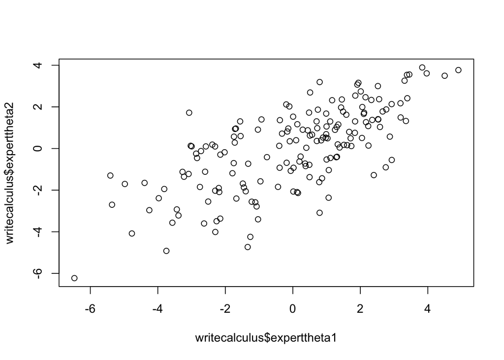

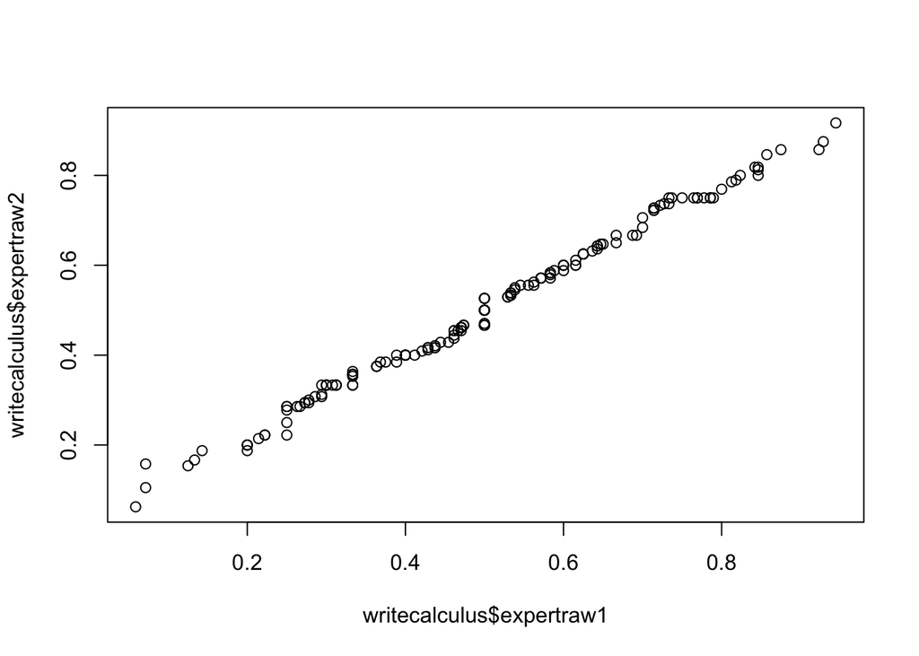

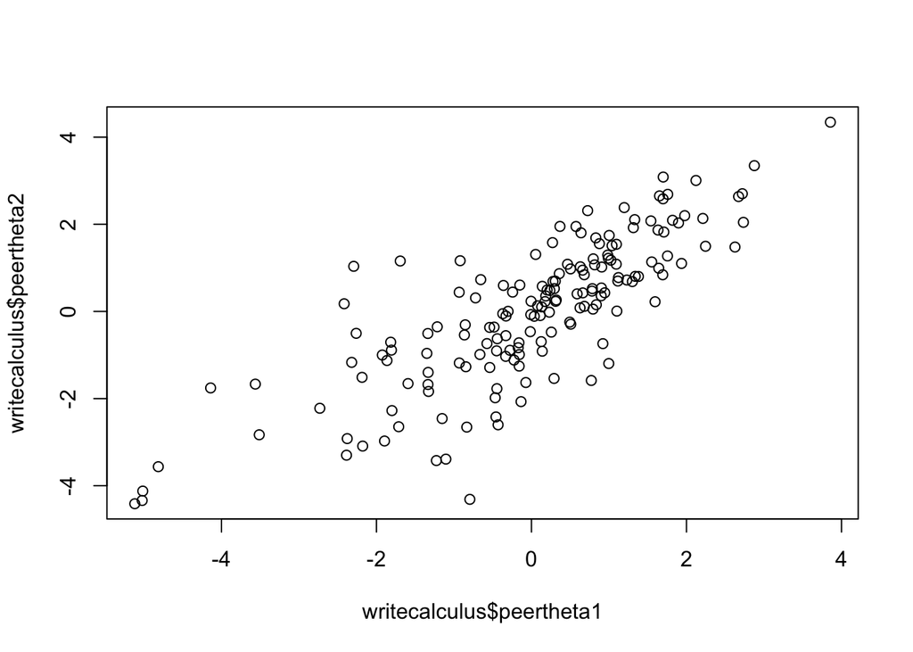

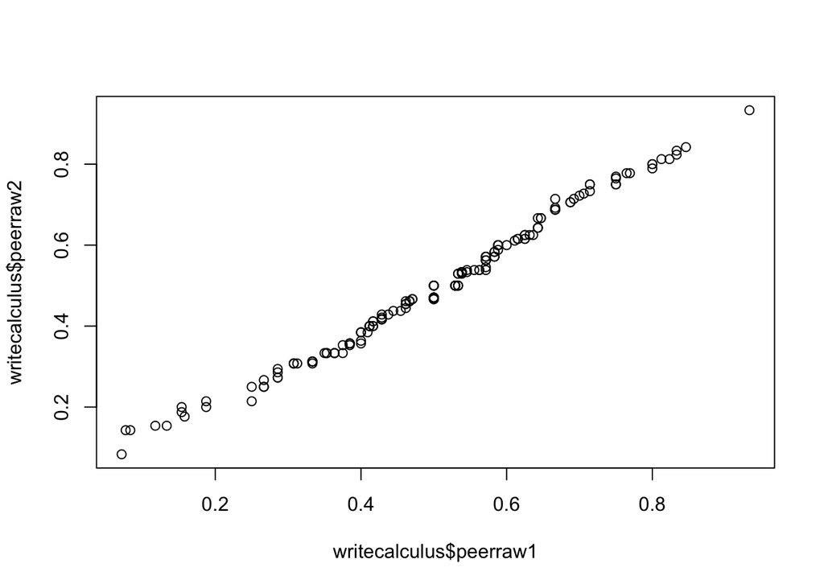

Correlation tests: experts

```
## $statistic
## [1] 7.412101
##
## $distribution
## [1] "z"
##
## $p.value
## [1] 1.24345e-13
```

Correlation tests: peers

```
## $statistic
## [1] 2.651009
##
## $distribution
## [1] "z"
##
## $p.value
## [1] 0.008025166
```

Correlation tests: mean expert, mean peer

```
## $statistic
## [1] 3.928736
##
## $distribution
## [1] "z"
##
## $p.value
## [1] 8.539358e-05
```

Spearman correlations

```
##                 thetaexpert1 rawexpert1 thetaexpert2 rawexpert2 thetanovice
## thetaexpert1           1.000      0.824        0.834      0.493       0.617
## rawexpert1             0.824      1.000        0.619      0.419       0.463
## thetaexpert2           0.834      0.619        1.000      0.817       0.544
## rawexpert2             0.493      0.419        0.817      1.000       0.322
## thetanovice            0.617      0.463        0.544      0.322       1.000
## rawnovice              0.529      0.397        0.427      0.209       0.633
## thetapeer1             0.744      0.573        0.672      0.443       0.652
## rawpeer1               0.598      0.440        0.515      0.306       0.549
## thetapeer2             0.600      0.384        0.582      0.412       0.627
## rawpeer2               0.567      0.358        0.559      0.420       0.563
## thetameanexpert        0.961      0.759        0.949      0.671       0.605
## rawmeanexpert          0.786      0.840        0.849      0.829       0.459
## thetameanpeer          0.727      0.515        0.680      0.462       0.692
## rawmeanpeer            0.661      0.450        0.614      0.415       0.635
##                 rawnovice thetapeer1 rawpeer1 thetapeer2 rawpeer2
## thetaexpert1        0.529      0.744    0.598      0.600    0.567
## rawexpert1          0.397      0.573    0.440      0.384    0.358
## thetaexpert2        0.427      0.672    0.515      0.582    0.559
## rawexpert2          0.209      0.443    0.306      0.412    0.420
## thetanovice         0.633      0.652    0.549      0.627    0.563
## rawnovice           1.000      0.572    0.524      0.530    0.456
## thetapeer1          0.572      1.000    0.882      0.661    0.600
## rawpeer1            0.524      0.882    1.000      0.549    0.508
## thetapeer2          0.530      0.661    0.549      1.000    0.897
## rawpeer2            0.456      0.600    0.508      0.897    1.000
## thetameanexpert     0.498      0.738    0.586      0.616    0.589
## rawmeanexpert       0.353      0.595    0.445      0.466    0.460
## thetameanpeer       0.594      0.886    0.756      0.925    0.832
## rawmeanpeer         0.555      0.846    0.848      0.837    0.872
##                 thetameanexpert rawmeanexpert thetameanpeer rawmeanpeer
## thetaexpert1              0.961         0.786         0.727       0.661
## rawexpert1                0.759         0.840         0.515       0.450
## thetaexpert2              0.949         0.849         0.680       0.614
## rawexpert2                0.671         0.829         0.462       0.415
## thetanovice               0.605         0.459         0.692       0.635
## rawnovice                 0.498         0.353         0.594       0.555
## thetapeer1                0.738         0.595         0.886       0.846
## rawpeer1                  0.586         0.445         0.756       0.848
## thetapeer2                0.616         0.466         0.925       0.837
## rawpeer2                  0.589         0.460         0.832       0.872
## thetameanexpert           1.000         0.853         0.734       0.670
## rawmeanexpert             0.853         1.000         0.573       0.513
## thetameanpeer             0.734         0.573         1.000       0.921
## rawmeanpeer               0.670         0.513         0.921       1.000
```

Mean module scores

```
## [1] 0.344
```

Expert and peer mean module score correlations (theta and raw)

```
##       CW1   compcw1   compcw2 classtest       CW2
## 0.2994834 0.2373367 0.2473554 0.4325480 0.4919594
```

```
## [1] 0.342
```

```
##       CW1   compcw1   compcw2 classtest       CW2
## 0.2283234 0.1485728 0.1905195 0.4264715 0.4447138
```

```
## [1] 0.288
```

```
##
##  Wilcoxon signed rank exact test
##
## data:  expertcorreltheta and expertcorrelraw
## V = 15, p-value = 0.0625
## alternative hypothesis: true location shift is not equal to 0
```

```
## [1] -1.862732
```

```
##       CW1   compcw1   compcw2 classtest       CW2
## 0.2391397 0.1623829 0.1443003 0.3322351 0.3247800
```

```
## [1] 0.241
```

```
##       CW1   compcw1   compcw2 classtest       CW2
## 0.2490064 0.1852392 0.1211314 0.3618345 0.2649697
```

```
## [1] 0.236
```

```
##
##  Wilcoxon signed rank exact test
##
## data:  peercorreltheta and peercorrelraw
## V = 8, p-value = 1
## alternative hypothesis: true location shift is not equal to 0
```

```
## [1] 0
```

Novice and mean expert correlations

```
## [1] 0.629
```

```
## [1] 0.391
```

```
## $statistic
## [1] 2.966238
##
## $distribution
## [1] "z"
##
## $p.value
## [1] 0.003014669
```

File size and mean expert (theta and raw)

```
##
##  Shapiro-Wilk normality test
##
## data:  scoresandachievement$filesize
## W = 0.96126, p-value = 0.0001282
```

```
## [1] 0.461
```

```
## [1] 0.346
```

```
## [1] 0.859
```

```
## $distribution
## [1] "z"
##
## $statistic
## [1] 3.064551
##
## $p.value
## [1] 0.002179972
```

```
## [1] 0.514
```

```
## [1] 0.456
```

```
## [1] 0.918
```

```
## $distribution
## [1] "z"
##
## $statistic
## [1] 2.124742
##
## $p.value
## [1] 0.03360811
```

File size and experts vs novices: theta then raw

```
## $distribution
## [1] "z"
##
## $statistic
## [1] 0.9363761
##
## $p.value
## [1] 0.3490796
```

```
## $distribution
## [1] "z"
##
## $statistic
## [1] 1.442035
##
## $p.value
## [1] 0.1492925
```

### SHE2014 reliabilities with close pairings removed

EXPERT 1

Number of judges =

```
## [1] 11
```

List of number of judgements per judge =

```
##  [1]  28  39  41  42  44  47  52  56 104 162 188
```

```
## [1] 803
```

Number of scripts =

```
## [1] 168
```

List of number of judgements per script =

```
## [1] 9
```

```
##   [1]  1  2  4  4  4  4  5  5  5  5  5  5  5  5  5  6  6  6  6  6  6  6  6  6  6
##  [26]  6  6  6  6  6  6  7  7  7  7  7  7  7  7  7  7  7  7  7  7  7  7  7  7  8
##  [51]  8  8  8  8  8  8  8  8  8  8  8  8  8  9  9  9  9  9  9  9  9  9  9  9  9
##  [76]  9  9  9  9  9  9  9  9  9  9  9  9  9  9  9 10 10 10 10 10 10 10 10 10 10
## [101] 10 10 10 10 10 10 10 10 10 11 11 11 11 11 11 11 11 11 11 11 11 12 12 12 12
## [126] 12 12 12 12 12 12 12 13 13 13 13 13 13 13 13 13 13 13 13 13 13 14 14 14 14
## [151] 14 14 14 14 14 14 15 15 15 15 15 15 16 16 16 17 17 17
```

SSR=

```
## [1] 0.818
```

Count of 1s and 0s in raw, Correlation of theta and raw

```
## [1] 9
```

```
## [1] 3
```

```
## [1] 0.07142857
```

```
## [1] 0.8193888
```

EXPERT 2

Number of judges =

```
## [1] 11
```

List of number of judgements per judge =

```
##  [1]  35  40  41  42  46  51  52  95 119 122 169
```

```
## [1] 812
```

Number of scripts =

```
## [1] 168
```

List of number of judgements per script =

```
## [1] 10
```

```
##   [1]  2  3  4  4  4  4  4  5  5  5  5  5  6  6  6  6  6  6  6  6  6  6  6  6  6
##  [26]  7  7  7  7  7  7  7  7  7  7  7  7  7  7  7  7  7  7  7  8  8  8  8  8  8
##  [51]  8  8  8  8  8  8  8  8  8  8  8  8  8  8  9  9  9  9  9  9  9  9  9  9  9
##  [76]  9  9  9  9  9  9  9 10 10 10 10 10 10 10 10 10 10 10 10 10 10 10 10 10 10
## [101] 10 10 10 11 11 11 11 11 11 11 11 11 11 11 11 11 11 11 11 11 11 11 12 12 12
## [126] 12 12 12 12 12 12 12 12 12 13 13 13 13 13 13 13 13 13 13 13 13 13 13 13 13
## [151] 14 14 14 14 14 14 14 14 14 14 15 15 15 15 16 17 18 19
```

SSR=

```
## [1] 0.799
```

Count of 1s and 0s in raw, Correlation of theta and raw

```
## [1] 0
```

```
## [1] 2
```

```
## [1] 0.01190476
```

```
## [1] 0.7601247
```

Expert inter-rater

```
## [1] 0.6362761
```

```
## [1] 0.9860139
```

```
## $statistic
## [1] -15.67735
##
## $distribution
## [1] "z"
##
## $p.value
## [1] 0
```

PEER 1

Number of judges =

```
## [1] 101
```

List of number of judgements per judge =

```
##   [1]  2  3  3  3  4  4  4  4  5  5  5  5  5  5  6  6  6  6  6  6  6  6  6  6  6
##  [26]  6  6  6  6  6  6  6  6  6  6  7  7  7  7  7  7  7  7  7  7  7  7  7  7  8
##  [51]  8  8  8  8  8  8  8  8  8  8  8  9  9  9  9  9  9  9  9  9  9  9  9  9  9
##  [76] 10 10 10 10 10 10 10 10 10 10 10 11 11 11 11 12 12 12 12 13 13 14 15 17 17
## [101] 18
```

```
## [1] 812
```

Number of scripts =

```
## [1] 169
```

List of number of judgements per script =

```
## [1] 9
```

```
##   [1]  4  4  4  4  4  4  5  5  5  6  6  6  6  6  6  6  6  6  7  7  7  7  7  7  7
##  [26]  7  7  7  7  7  7  7  7  7  7  7  7  7  7  7  7  8  8  8  8  8  8  8  8  8
##  [51]  8  8  8  8  8  8  8  8  8  8  8  8  8  8  8  8  8  8  9  9  9  9  9  9  9
##  [76]  9  9  9  9  9  9  9  9  9  9  9  9  9  9  9  9 10 10 10 10 10 10 10 10 10
## [101] 10 10 10 10 10 10 10 10 10 10 11 11 11 11 11 11 11 11 11 11 11 11 11 11 11
## [126] 11 11 11 11 12 12 12 12 12 12 12 12 12 12 12 12 12 12 12 12 13 13 13 13 13
## [151] 13 13 13 13 13 14 14 14 14 14 14 15 15 15 15 15 16 17 34
```

SSR=

```
## [1] 0.673
```

Count of 1s and 0s in raw, Correlation of theta and raw

```
## [1] 1
```

```
## [1] 0
```

```
## [1] 0.00591716
```

```
## [1] 0.8203823
```

PEER 2

Number of judges =

```
## [1] 91
```

List of number of judgements per judge =

```
##  [1]  1  3  3  4  5  5  6  6  6  6  6  6  6  6  7  7  7  7  7  7  7  7  7  7  7
## [26]  7  7  7  7  7  7  7  8  8  8  8  8  8  8  8  8  8  8  8  8  8  9  9  9  9
## [51]  9  9  9  9  9  9  9  9  9  9 10 10 10 10 10 10 10 10 10 10 10 10 10 10 11
## [76] 11 11 11 12 12 12 12 13 13 13 14 15 15 16 18 18
```

```
## [1] 800
```

Number of scripts =

```
## [1] 168
```

List of number of judgements per script =

```
## [1] 9
```

```
##   [1]  3  4  4  5  5  5  5  6  6  6  6  6  6  6  6  6  7  7  7  7  7  7  7  7  7
##  [26]  7  7  7  7  7  7  7  7  7  7  7  7  7  7  8  8  8  8  8  8  8  8  8  8  8
##  [51]  8  8  8  8  8  8  8  8  8  9  9  9  9  9  9  9  9  9  9  9  9  9  9  9  9
##  [76]  9  9  9  9  9  9  9  9  9  9  9  9  9  9  9  9  9 10 10 10 10 10 10 10 10
## [101] 10 10 10 10 10 10 10 10 10 10 10 10 11 11 11 11 11 11 11 11 11 11 11 11 11
## [126] 11 11 11 11 11 11 11 11 12 12 12 12 12 12 12 12 12 12 12 12 13 13 13 13 13
## [151] 13 13 13 13 13 14 14 14 14 14 14 14 15 15 15 16 16 17
```

SSR=

```
## [1] 0.697
```

Count of 1s and 0s in raw, Correlation of theta and raw

```
## [1] 0
```

```
## [1] 1
```

```
## [1] 0.005952381
```

```
## [1] 0.8550322
```

## IJSME 2014: analysis

### IJSME 2014: GCSE 030211

Number of judges =

```
## [1] 12
```

List of number of judgements per judge =

```
##  [1]  7  8  9 10 13 14 15 15 15 15 15 15
```

```
## [1] 151
```

Number of scripts =

```
## [1] 18
```

List of number of judgements per script =

```
## [1] 17.5
```

```
##  [1] 13 13 13 13 13 14 15 17 17 18 18 18 19 19 19 20 21 22
```

SSR=

```
## [1] 0.776
```

Count of 1s and 0s in raw, Correlation of theta and raw

```
## [1] 0
```

```
## [1] 0
```

```
## [1] 0
```

```
## [1] 0.9695067
```

Judgement quality, theta then raw (then raw matches)

```
## [1] 0.7350993
```

```
## [1] 0.7152318
```

```
## [1] 0.006622517
```

Probability measure, quantile then correlation of FS and RS probabilities

```
##        0%       25%       50%       75%      100%
## 0.5020323 0.6329350 0.7529915 0.8911388 0.9854373
```

```
##         0%        25%        50%        75%       100%
## 0.00000000 0.02066491 0.05503922 0.08007394 0.16891829
```

```
## [1] 0.8862795
```

Pairings measure, quantile then correlation of pairing differences and probabilities

```
##         0%        25%        50%        75%       100%
## 0.01917656 0.44987176 0.81727289 1.40489762 2.88893988
```

```
## [1] 0.4226412
```

```
##          0%         25%         50%         75%        100%
## 0.002769361 0.478753948 0.859520152 1.434191430 2.899124067
```

```
## [1] 0.5176343
```

###Judge misfits

Number of misfits=

```
## [1] 1
```

Misfit threshold (2 SDs above mean) =

```
## [1] 0.6746348
```

Table of misfits (shows ‘0 rows’ if na)

```
##   Judge    total   average
## 6     6 19.27462 0.6883794
```

###Script misfits

Number of misfits=

```
## [1] 1
```

Misfit threshold (2 SDs above mean) =

```
## [1] 3.583463
```

Table of misfits (shows ‘0 rows’ if na)

```
##    candidate      wms
## 17        17 5.008467
```

### IJSME 2014: GCSE 070211

Number of judges =

```
## [1] 11
```

List of number of judgements per judge =

```
##  [1]  6  7 10 10 15 17 17 17 17 17 17
```

```
## [1] 150
```

Number of scripts =

```
## [1] 18
```

List of number of judgements per script =

```
## [1] 16
```

```
##  [1] 12 13 13 13 14 14 15 15 15 17 17 18 18 19 20 21 23 23
```

SSR=

```
## [1] 0.903
```

Count of 1s and 0s in raw, Correlation of theta and raw

```
## [1] 0
```

```
## [1] 1
```

```
## [1] 0.05555556
```

```
## [1] 0.9526625
```

Judgement quality, theta then raw (then raw matches)

```
## [1] 0.8533333
```

```
## [1] 0.7866667
```

```
## [1] 0.02
```

Probability measure, quantile then correlation of FS and RS probabilities

```
##        0%       25%       50%       75%      100%
## 0.5010214 0.7182653 0.8543389 0.9793368 0.9999099
```

```
##         0%        25%        50%        75%       100%
## 0.00000000 0.02833097 0.06901614 0.09598611 0.19552690
```

```
## [1] 0.7542479
```

Pairings measure, quantile then correlation of pairing differences and probabilities

```
##         0%        25%        50%        75%       100%
## 0.03231009 0.39783423 0.71740923 1.07131797 2.95794684
```

```
## [1] 0.04815833
```

```
##          0%         25%         50%         75%        100%
## 0.001703369 0.451215617 0.732070158 1.343596761 2.744863867
```

```
## [1] 0.3351676
```

###Judge misfits

Number of misfits=

```
## [1] 0
```

Misfit threshold (2 SDs above mean) =

```
## [1] 0.7673426
```

Table of misfits (shows ‘0 rows’ if na)

```
## [1] Judge   total   average
## <0 rows> (or 0-length row.names)
```

###Script misfits

Number of misfits=

```
## [1] 1
```

Misfit threshold (2 SDs above mean) =

```
## [1] 10.42978
```

Table of misfits (shows ‘0 rows’ if na)

```
##    candidate      wms
## 17        17 15.30621
```

Inter-rater, theta then raw

```
## [1] 0.9084612
```

```
## [1] 0.9707476
```

```
## $statistic
## [1] -1.606081
##
## $distribution
## [1] "z"
##
## $p.value
## [1] 0.1082561
```

### GCSE Validity, theta then raw

```
## [1] 0.846096
```

```
## [1] 0.881085
```

```
## $distribution
## [1] "z"
##
## $statistic
## [1] -1.228711
##
## $p.value
## [1] 0.2191803
```

### IJSME 2014: Bowland 030211

Number of judges =

```
## [1] 12
```

List of number of judgements per judge =

```
##  [1]  9 14 15 15 15 15 15 15 15 15 15 15
```

```
## [1] 173
```

Number of scripts =

```
## [1] 18
```

List of number of judgements per script =

```
## [1] 22
```

```
##  [1] 11 12 12 12 13 13 16 22 22 22 22 23 23 23 23 24 26 27
```

SSR=

```
## [1] 0.853
```

Count of 1s and 0s in raw, Correlation of theta and raw

```
## [1] 1
```

```
## [1] 0
```

```
## [1] 0.05555556
```

```
## [1] 0.9352262
```

Judgement quality, theta then raw (then raw matches)

```
## [1] 0.8150289
```

```
## [1] 0.7861272
```

```
## [1] 0
```

Probability measure, quantile then correlation of FS and RS probabilities

```
##        0%       25%       50%       75%      100%
## 0.5044669 0.6977382 0.7993156 0.9485602 0.9996775
```

```
##           0%          25%          50%          75%         100%
## 0.0004180601 0.0340381803 0.0677623235 0.0954070132 0.2128140986
```

```
## [1] 0.7925442
```

Pairings measure, quantile then correlation of pairing differences and probabilities

```
##          0%         25%         50%         75%        100%
## 0.006233336 0.356317559 0.735930857 1.286810235 3.934435679
```

```
## [1] 0.2479468
```

```
##          0%         25%         50%         75%        100%
## 0.005128023 0.364727267 0.879919331 1.528539678 3.322731422
```

```
## [1] 0.4362221
```

###Judge misfits

Number of misfits=

```
## [1] 1
```

Misfit threshold (2 SDs above mean) =

```
## [1] 0.6961134
```

Table of misfits (shows ‘0 rows’ if na)

```
##    Judge    total   average
## 11    11 15.31751 0.6962504
```

###Script misfits

Number of misfits=

```
## [1] 1
```

Misfit threshold (2 SDs above mean) =

```
## [1] 12.71809
```

Table of misfits (shows ‘0 rows’ if na)

```
##    candidate      wms
## 17        17 20.30641
```

### IJSME 2014: Bowland 070211

Number of judges =

```
## [1] 11
```

List of number of judgements per judge =

```
##  [1]  6  9 12 12 13 13 14 15 16 16 17
```

```
## [1] 143
```

Number of scripts =

```
## [1] 18
```

List of number of judgements per script =

```
## [1] 17
```

```
##  [1]  8 10 10 10 10 10 10 17 17 17 18 19 19 20 21 22 24 24
```

SSR=

```
## [1] 0.87
```

Count of 1s and 0s in raw, Correlation of theta and raw

```
## [1] 2
```

```
## [1] 1
```

```
## [1] 0.1666667
```

```
## [1] 0.9368016
```

Judgement quality, theta then raw (then raw matches)

```
## [1] 0.8881119
```

```
## [1] 0.8531469
```

```
## [1] 0.006993007
```

Probability measure, quantile then correlation of FS and RS probabilities

```
##        0%       25%       50%       75%      100%
## 0.5076498 0.7327651 0.9620825 0.9874797 0.9999548
```

```
##         0%        25%        50%        75%       100%
## 0.00000000 0.04323541 0.07888108 0.12357905 0.23105858
```

```
## [1] 0.5990462
```

Pairings measure, quantile then correlation of pairing differences and probabilities

```
##         0%        25%        50%        75%       100%
## 0.00396741 0.40300892 0.67610859 1.13626889 2.97219836
```

```
## [1] -0.2264718
```

```
##         0%        25%        50%        75%       100%
## 0.06594399 0.32294855 0.83311427 1.42710791 3.05389059
```

```
## [1] 0.2952692
```

Inter-rater, theta then raw

```
## [1] 0.8837118
```

```
## [1] 0.9836636
```

```
## $statistic
## [1] -2.758302
##
## $distribution
## [1] "z"
##
## $p.value
## [1] 0.005810255
```

### BOWLAND Validity, theta then raw

```
## [1] 0.8363573
```

```
## [1] 0.8131021
```

```
## $distribution
## [1] "z"
##
## $statistic
## [1] 0.5883705
##
## $p.value
## [1] 0.5562837
```

## ESM 2015

### ESM 2015: All judgements

Number of judges =

```
## [1] 15
```

List of number of judgements per judge =

```
##  [1] 176 198 210 214 226 228 230 235 241 242 274 278 281 283 291
```

```
## [1] 3607
```

Number of scripts =

```
## [1] 750
```

List of number of judgements per script =

```
## [1] 9
```

```
##   [1]  6  7  7  7  7  7  7  8  8  8  8  8  8  8  8  8  8  8  8  8  8  8  8  8  8
##  [26]  8  8  8  8  8  8  8  8  8  8  8  8  8  8  8  8  8  8  8  8  8  8  8  8  8
##  [51]  8  8  8  8  8  8  8  8  8  8  8  8  8  8  8  8  8  9  9  9  9  9  9  9  9
##  [76]  9  9  9  9  9  9  9  9  9  9  9  9  9  9  9  9  9  9  9  9  9  9  9  9  9
## [101]  9  9  9  9  9  9  9  9  9  9  9  9  9  9  9  9  9  9  9  9  9  9  9  9  9
## [126]  9  9  9  9  9  9  9  9  9  9  9  9  9  9  9  9  9  9  9  9  9  9  9  9  9
## [151]  9  9  9  9  9  9  9  9  9  9  9  9  9  9  9  9  9  9  9  9  9  9  9  9  9
## [176]  9  9  9  9  9  9  9  9  9  9  9  9  9  9  9  9  9  9  9  9  9  9  9  9  9
## [201]  9  9  9  9  9  9  9  9  9  9  9  9  9  9  9  9  9  9  9  9  9  9  9  9  9
## [226]  9  9  9  9  9  9  9  9  9  9  9  9  9  9  9  9  9  9  9  9  9  9  9  9  9
## [251]  9  9  9  9  9  9  9  9  9  9  9  9  9  9  9  9  9  9  9  9  9  9  9  9  9
## [276]  9  9  9  9  9  9  9  9  9  9  9  9  9  9  9  9  9  9  9  9  9  9  9  9  9
## [301]  9  9  9  9  9  9  9  9  9  9  9  9  9  9  9  9  9  9  9  9  9  9  9  9  9
## [326]  9  9  9  9  9  9  9  9  9  9  9  9  9  9  9  9  9  9  9  9  9  9  9  9  9
## [351]  9  9  9  9  9  9  9  9  9  9  9  9  9  9  9  9  9  9  9  9  9  9  9  9  9
## [376]  9  9  9  9  9  9  9  9  9  9  9  9  9  9  9  9  9  9  9  9  9  9  9  9  9
## [401]  9  9  9  9  9  9  9  9  9  9  9  9  9  9  9  9  9  9  9  9  9  9  9  9  9
## [426]  9  9  9  9  9  9  9  9  9  9  9  9  9  9  9 10 10 10 10 10 10 10 10 10 10
## [451] 10 10 10 10 10 10 10 10 10 10 10 10 10 10 10 10 10 10 10 10 10 10 10 10 10
## [476] 10 10 10 10 10 10 10 10 10 10 10 10 10 10 10 10 10 10 10 10 10 10 10 10 10
## [501] 10 10 10 10 10 10 10 10 10 10 10 10 10 10 10 10 10 10 10 10 10 10 10 10 10
## [526] 10 10 10 10 10 10 10 10 10 10 10 10 10 10 10 10 10 10 10 10 10 10 11 11 11
## [551] 11 11 11 11 11 11 11 11 11 11 11 11 11 11 11 11 11 11 11 11 11 11 11 11 11
## [576] 11 11 11 11 11 11 11 11 11 11 11 11 11 11 11 11 11 11 11 11 11 11 11 11 11
## [601] 11 11 11 11 11 11 11 11 11 11 11 11 11 11 11 11 11 11 11 11 11 11 11 11 11
## [626] 11 11 11 11 11 11 11 11 11 11 11 11 11 11 11 11 11 11 11 11 11 11 11 11 11
## [651] 11 11 11 11 11 11 11 11 11 11 11 11 11 11 11 11 11 11 11 11 11 11 11 11 11
## [676] 11 11 11 11 11 11 11 11 11 11 11 11 11 11 11 11 11 11 11 11 11 11 11 11 11
## [701] 11 11 11 11 11 11 11 11 11 11 11 11 11 11 11 11 11 11 11 11 11 11 11 11 11
## [726] 11 11 11 11 11 11 11 11 11 11 11 11 11 11 11 11 12 12 12 12 12 12 13 13 27
```

SSR=

```
## [1] 0.971
```

Count of 1s and 0s in raw, Correlation of theta and raw

```
## [1] 2
```

```
## [1] 8
```

```
## [1] 0.01333333
```

```
## [1] 0.7480669
```

Judgement quality, theta then raw (then raw matches)

```
## [1] 0.9564735
```

```
## [1] 0.7291378
```

```
## [1] 0.07513169
```

Probability measure, quantile then correlation of FS and RS probabilities

```
##        0%       25%       50%       75%      100%
## 0.5014955 0.7574477 0.9123372 0.9946882 1.0000000
```

```
##         0%        25%        50%        75%       100%
## 0.00000000 0.02271163 0.04532974 0.07518313 0.18520098
```

```
## [1] 0.3146415
```

Pairings measure, quantile then correlation of pairing differences and probabilities

```
##           0%          25%          50%          75%         100%
## 0.0000675817 0.2241386334 0.3823217462 0.5349155157 3.6432604707
```

```
## [1] 0.02709279
```

```
##          0%         25%         50%         75%        100%
## 0.003715099 0.372528700 0.813673273 1.359234791 4.305823986
```

```
## [1] 0.5624605
```

###Judge misfits

Number of misfits=

```
## [1] 0
```

Misfit threshold (2 SDs above mean) =

```
## [1] 0.9644559
```

Table of misfits (shows ‘0 rows’ if na)

```
## [1] Judge   total   average
## <0 rows> (or 0-length row.names)
```

###Script misfits

Number of misfits=

```
## [1] 31
```

Misfit threshold (2 SDs above mean) =

```
## [1] 0.9658169
```

Table of misfits (shows ‘0 rows’ if na)

```
##     candidate       wms
## 696       855 0.9717802
## 490       585 0.9827364
## 400       479 1.0098569
## 153       208 1.0111463
## 571       699 1.0146689
## 678       835 1.0184655
## 442       521 1.0221818
## 479       569 1.0241456
## 745       917 1.0304898
## 398       477 1.0355106
## 456       538 1.0453112
## 642       796 1.0546768
## 55         67 1.0572581
## 659       816 1.0670983
```

[output cut: 17 more lines]

Validity, for marks and GCSE grade (theta then raw)

```
## [1] 0.871117
```

```
## [1] 0.7252902
```

```
## $distribution
## [1] "z"
##
## $statistic
## [1] 14.42733
##
## $p.value
## [1] 0
```

```
## [1] 0.7247631
```

```
## [1] 0.5925582
```

```
## $distribution
## [1] "z"
##
## $statistic
## [1] 9.804842
##
## $p.value
## [1] 0
```

Number of judges =

```
## [1] 5
```

List of number of judgements per judge =

```
## [1] 250 250 250 250 250
```

```
## [1] 1250
```

Number of scripts =

```
## [1] 250
```

List of number of judgements per script =

```
## [1] 10
```

```
##   [1]  8  8  8  8  8  8  8  8  8  8  8  8  8  8  8  8  8  8  8  8  8  8  8  8  8
##  [26]  8  8  8  8  8  8  8  8  8  8  8  8  8  8  8  8  8  8  8  8  8  8  8  8  8
##  [51]  8  8  8  8  8  8  8  8  8  8  8  8  8  8  8  8  8  8  8  8  8  8  8  8  8
##  [76]  8  8  8  8  8  8  8  8  8  8  8  8  8  8  9  9  9  9  9 10 10 10 10 10 10
## [101] 10 10 10 10 10 10 10 10 10 10 10 10 10 10 10 10 10 10 10 10 10 10 10 10 10
## [126] 10 10 10 10 10 10 10 10 10 10 10 10 10 10 10 10 10 10 10 10 10 10 10 10 10
## [151] 10 10 10 10 10 10 10 10 10 10 10 10 10 10 10 10 10 10 10 10 10 10 10 10 10
## [176] 10 10 10 10 10 10 10 10 10 10 10 10 10 10 10 10 10 10 10 10 10 10 10 10 10
## [201] 10 10 10 10 10 10 10 10 10 10 10 10 10 10 10 10 10 10 10 10 10 10 10 10 10
## [226] 10 10 10 10 10 10 10 10 10 10 10 10 10 10 10 10 14 22 22 30 34 34 38 39 40
```

SSR=

```
## [1] 0.96
```

Count of 1s and 0s in raw, Correlation of theta and raw

```
## [1] 1
```

```
## [1] 2
```

```
## [1] 0.012
```

```
## [1] 0.8071873
```

Judgement quality, theta then raw (then raw matches)

```
## [1] 0.9264
```

```
## [1] 0.7176
```

```
## [1] 0.116
```

Probability measure, quantile then correlation of FS and RS probabilities

```
##        0%       25%       50%       75%      100%
## 0.5018614 0.7282581 0.9017024 0.9900406 1.0000000
```

```
##         0%        25%        50%        75%       100%
## 0.00000000 0.02497919 0.04363869 0.07393292 0.19011427
```

```
## [1] 0.3835608
```

Pairings measure, quantile then correlation of pairing differences and probabilities

```
##           0%          25%          50%          75%         100%
## 0.0004700413 0.2197573156 0.4168470124 0.5878921760 3.7142113796
```

```
## [1] 0.03304198
```

```
##         0%        25%        50%        75%       100%
## 0.03475923 0.31010712 0.75279360 1.28328938 3.74534494
```

```
## [1] 0.5911158
```

###Judge misfits

Number of misfits=

```
## [1] 0
```

Misfit threshold (2 SDs above mean) =

```
## [1] 0.9538266
```

Table of misfits (shows ‘0 rows’ if na)

```
## [1] Judge   total   average
## <0 rows> (or 0-length row.names)
```

###Script misfits

Number of misfits=

```
## [1] 9
```

Misfit threshold (2 SDs above mean) =

```
## [1] 1.274356
```

Table of misfits (shows ‘0 rows’ if na)

```
##     candidate      wms
## 18         49 1.323681
## 174       599 1.475058
## 108       349 1.524037
## 36         97 1.612165
## 30         79 1.675007
## 164       553 1.833844
## 216       792 1.874775
## 234       859 2.056815
## 144       480 2.182881
```

Validity, for marks and GCSE grade (theta then raw)

```
## [1] 0.865754
```

```
## [1] 0.7075319
```

```
## $distribution
## [1] "z"
##
## $statistic
## [1] 8.602917
##
## $p.value
## [1] 0
```

```
## [1] 0.7356793
```

```
## [1] 0.58298
```

```
## $distribution
## [1] "z"
##
## $statistic
## [1] 6.416873
##
## $p.value
## [1] 1.391014e-10
```

Inter-rater reliability

```
## [1] 0.8828407
```

```
## [1] 0.5802398
```

```
## $statistic
## [1] 8.064489
##
## $distribution
## [1] "z"
##
## $p.value
## [1] 6.661338e-16
```

## SEE 2015: analysis

### SEE 2014: SchoolA

Number of judges =

```
## [1] 27
```

List of number of judgements per judge =

```
##  [1] 20 21 21 21 22 22 22 23 23 23 23 23 23 23 23 23 23 23 23 23 24 25 34 40 46
## [26] 46 57
```

```
## [1] 720
```

Number of scripts =

```
## [1] 24
```

List of number of judgements per script =

```
## [1] 60.5
```

```
##  [1] 53 54 56 57 58 58 58 60 60 60 60 60 61 61 61 61 61 62 62 63 63 63 63 65
```

SSR=

```
## [1] 0.881
```

Count of 1s and 0s in raw, Correlation of theta and raw

```
## [1] 0.9999999
```

Judgement quality, theta then raw (then raw matches)

```
## [1] 0.7180556
```

```
## [1] 0.7180556
```

```
## [1] 0
```

Probability measure, quantile then correlation of FS and RS probabilities

```
##        0%       25%       50%       75%      100%
## 0.5001597 0.5217870 0.5483850 0.5809849 0.6428726
```

```
##           0%          25%          50%          75%         100%
## 0.0001413228 0.0219979530 0.0488823675 0.0817606227 0.1442023682
```

```
## [1] 0.9999997
```

Pairings measure, quantile then correlation of pairing differences and probabilities

```
##           0%          25%          50%          75%         100%
## 0.0005251547 0.4885923115 1.0218056432 1.6475006013 3.7758911541
```

```
## [1] 0.6557518
```

```
##          0%         25%         50%         75%        100%
## 0.000153257 0.489944867 1.022822012 1.648166462 3.775227926
```

```
## [1] 0.6556957
```

###Judge misfits

Number of misfits=

```
## [1] 0
```

Misfit threshold (2 SDs above mean) =

```
## [1] 0.7325239
```

Table of misfits (shows ‘0 rows’ if na)

```
## [1] Judge   total   average
## <0 rows> (or 0-length row.names)
```

###Script misfits

Number of misfits=

```
## [1] 1
```

Misfit threshold (2 SDs above mean) =

```
## [1] 1.251948
```

Table of misfits (shows ‘0 rows’ if na)

```
##   candidate     wms
## 4        84 1.28187
```

### SEE 2014: schoolB

Number of judges =

```
## [1] 22
```

List of number of judgements per judge =

```
##  [1] 19 22 23 23 23 23 23 23 23 23 23 23 23 23 23 23 23 23 23 28 43 46
```

```
## [1] 549
```

Number of scripts =

```
## [1] 24
```

List of number of judgements per script =

```
## [1] 46
```

```
##  [1] 42 43 43 44 44 44 44 44 45 45 45 46 46 46 46 46 47 47 48 48 48 48 49 50
```

SSR=

```
## [1] 0.875
```

Count of 1s and 0s in raw, Correlation of theta and raw

```
## [1] 0.9999998
```

Judgement quality, theta then raw (then raw matches)

```
## [1] 0.7358834
```

```
## [1] 0.7358834
```

```
## [1] 0.001821494
```

Probability measure, quantile then correlation of FS and RS probabilities

```
##        0%       25%       50%       75%      100%
## 0.5000000 0.5270768 0.5551012 0.5887891 0.6596389
```

```
##         0%        25%        50%        75%       100%
## 0.00000000 0.02739922 0.05588794 0.08992041 0.16162214
```

```
## [1] 0.9999994
```

Pairings measure, quantile then correlation of pairing differences and probabilities

```
##          0%         25%         50%         75%        100%
## 0.003181995 0.419651854 0.987747652 1.621552556 4.149898980
```

```
## [1] 0.5896033
```

```
##          0%         25%         50%         75%        100%
## 0.003823052 0.420198582 0.988165563 1.622959884 4.150821835
```

```
## [1] 0.5894376
```

### SEE 2014: schoolC

Number of judges =

```
## [1] 27
```

List of number of judgements per judge =

```
##  [1] 21 22 23 23 23 23 23 23 23 23 23 23 23 23 23 23 23 23 23 23 23 23 25 28 39
## [26] 57 62
```

```
## [1] 714
```

Number of scripts =

```
## [1] 24
```

List of number of judgements per script =

```
## [1] 60
```

```
##  [1] 54 56 56 57 58 58 58 59 59 59 59 60 60 60 60 61 61 61 61 62 62 62 62 63
```

SSR=

```
## [1] 0.839
```

Count of 1s and 0s in raw, Correlation of theta and raw

```
## [1] 1
```

Judgement quality, theta then raw (then raw matches)

```
## [1] 0.6862745
```

```
## [1] 0.6862745
```

```
## [1] 0.008403361
```

Probability measure, quantile then correlation of FS and RS probabilities

```
##        0%       25%       50%       75%      100%
## 0.5000000 0.5179376 0.5445220 0.5623820 0.6328171
```

```
##         0%        25%        50%        75%       100%
## 0.00000000 0.01816196 0.04497242 0.06301410 0.13413559
```

```
## [1] 0.9999998
```

Pairings measure, quantile then correlation of pairing differences and probabilities

```
##          0%         25%         50%         75%        100%
## 0.007595603 0.534836957 0.932054173 1.565212322 4.358537498
```

```
## [1] 0.7370346
```

```
##          0%         25%         50%         75%        100%
## 0.007552629 0.534554461 0.931685672 1.564953930 4.357820157
```

```
## [1] 0.7370083
```

### SEE part 2: Reliability and validity stuff

```
##        thetaA  rawA thetaB  rawB thetaC  rawC theta   raw
## thetaA  1.000 1.000  0.925 0.925  0.836 0.836 0.800 0.662
## rawA    1.000 1.000  0.925 0.925  0.836 0.836 0.800 0.662
## thetaB  0.925 0.925  1.000 1.000  0.855 0.855 0.833 0.747
## rawB    0.925 0.925  1.000 1.000  0.855 0.855 0.833 0.747
## thetaC  0.836 0.836  0.855 0.855  1.000 1.000 0.739 0.789
## rawC    0.836 0.836  0.855 0.855  1.000 1.000 0.739 0.789
## theta   0.800 0.800  0.833 0.833  0.739 0.739 1.000 0.854
## raw     0.662 0.662  0.747 0.747  0.789 0.789 0.854 1.000
```

```
## $statistic
## [1] 0.0005482896
##
## $distribution
## [1] "z"
##
## $p.value
## [1] 0.9995625
```

```
## $statistic
## [1] 0.0002700177
##
## $distribution
## [1] "z"
##
## $p.value
## [1] 0.9997846
```

```
## $statistic
## [1] -0.000435897
##
## $distribution
## [1] "z"
##
## $p.value
## [1] 0.9996522
```

SEE all peer judgements together

Number of judges =

```
## [1] 76
```

List of number of judgements per judge =

```
##  [1] 19 20 21 21 21 21 22 22 22 22 22 23 23 23 23 23 23 23 23 23 23 23 23 23 23
## [26] 23 23 23 23 23 23 23 23 23 23 23 23 23 23 23 23 23 23 23 23 23 23 23 23 23
## [51] 23 23 23 23 23 23 23 23 23 23 23 24 25 25 28 28 34 39 40 43 46 46 46 57 57
## [76] 62
```

```
## [1] 1983
```

Number of scripts =

```
## [1] 24
```

List of number of judgements per script =

```
## [1] 166
```

```
##  [1] 155 155 160 160 161 163 163 164 164 165 165 166 166 166 167 167 168 168 168
## [20] 168 170 171 172 174
```

SSR=

```
## [1] 0.95
```

Count of 1s and 0s in raw, Correlation of theta and raw

```
## [1] 0
```

```
## [1] 0
```

```
## [1] 0
```

```
## [1] 1
```

Judgement quality, theta then raw (then raw matches)

```
## [1] 0.6949067
```

```
## [1] 0.6949067
```

```
## [1] 0
```

Probability measure, quantile then correlation of FS and RS probabilities

```
##        0%       25%       50%       75%      100%
## 0.5001368 0.5201173 0.5473495 0.5739290 0.6264626
```

```
##           0%          25%          50%          75%         100%
## 0.0001293996 0.0201896863 0.0475267108 0.0741915601 0.1268946714
```

```
## [1] 1
```

Pairings measure, quantile then correlation of pairing differences and probabilities

```
##         0%        25%        50%        75%       100%
## 0.00289003 0.51182692 0.98101925 1.63777121 3.87182531
```

```
## [1] 0.6869343
```

```
##        0%       25%       50%       75%      100%
## 0.0028562 0.5118240 0.9808471 1.6378050 3.8718779
```

```
## [1] 0.6869186
```

###Judge misfits

Number of misfits=

```
## [1] 0
```

Misfit threshold (2 SDs above mean) =

```
## [1] 0.7234932
```

Table of misfits (shows ‘0 rows’ if na)

```
## [1] Judge   total   average
## <0 rows> (or 0-length row.names)
```

###Script misfits

Number of misfits=

```
## [1] 2
```

Misfit threshold (2 SDs above mean) =

```
## [1] 1.109525
```

Table of misfits (shows ‘0 rows’ if na)

```
##    candidate      wms
## 1         81 1.112361
## 11        92 1.114671
```

Inter-rater reliability, theta then raw

```
## [1] 0.918
```

```
## [1] 0.986
```

```
## $statistic
## [1] -2.905943
##
## $distribution
## [1] "z"
##
## $p.value
## [1] 0.003661477
```

Validity, peer vs expert thetas then raw

```
## [1] 0.827216
```

```
## [1] 0.7616617
```

```
## $statistic
## [1] 0.5803257
##
## $distribution
## [1] "z"
##
## $p.value
## [1] 0.561695
```

Validity by achievement data, younger students (thetas then raw) then older students (thetas then raw)

```
## [1] 10
```

```
## [1] 14
```

```
## [1] 0.4290256
```

```
## [1] 0.5725517
```

```
##
##  Wilcoxon rank sum exact test
##
## data:  SEE_younger$thetaPeer by SEE_younger$level
## W = 4, p-value = 0.1143
## alternative hypothesis: true location shift is not equal to 0
```

```
## [1] -1.57922
```

```
## [1] 0.4287626
```

```
## [1] 0.5728199
```

```
##
##  Wilcoxon rank sum exact test
##
## data:  SEE_younger$rawPeer by SEE_younger$level
## W = 4, p-value = 0.1143
## alternative hypothesis: true location shift is not equal to 0
```

```
## [1] -1.57922
```

```
## [1] 0.7159983
```

```
## [1] 0.7159983
```

## Alevel BERJ 2015 (imperfect)

### Basic stuff

Number of judges =

```
## [1] 10
```

List of number of judgements per judge =

```
##  [1] 189 189 189 189 189 189 189 189 189 189
```

Number of scripts =

```
## [1] 189
```

List of number of judgements per script =

```
## [1] 20
```

```
##   [1] 18 18 18 18 19 19 19 19 19 19 19 19 19 19 19 19 19 19 19 19 19 19 19 19 19
##  [26] 19 19 19 19 19 19 19 19 19 19 19 19 19 19 19 19 19 19 19 19 20 20 20 20 20
##  [51] 20 20 20 20 20 20 20 20 20 20 20 20 20 20 20 20 20 20 20 20 20 20 20 20 20
##  [76] 20 20 20 20 20 20 20 20 20 20 20 20 20 20 20 20 20 20 20 20 20 20 20 20 20
## [101] 20 20 20 20 20 20 20 20 20 20 20 20 20 20 20 20 20 20 20 20 20 20 20 20 20
## [126] 20 20 20 20 20 20 20 20 20 20 20 20 20 20 20 20 20 20 21 21 21 21 21 21 21
## [151] 21 21 21 21 21 21 21 21 21 21 21 21 21 21 21 21 21 21 21 21 21 21 21 21 21
## [176] 21 21 21 21 21 21 21 21 21 21 21 22 22 22
```

SSR=

```
## [1] 0.869
```

Count of 1s and 0s in raw, Correlation of theta and raw

```
## [1] 2
```

```
## [1] 3
```

```
## [1] 0.02645503
```

```
## [1] 0.958565
```

Judgement quality, theta then raw (then raw matches)

```
## [1] 0.8661376
```

```
## [1] 0.8306878
```

```
## [1] 0.02275132
```

Probability measure, quantile then correlation of FS and RS probabilities

```
##        0%       25%       50%       75%      100%
## 0.5001847 0.7254620 0.8902923 0.9706053 0.9999766
```

```
##         0%        25%        50%        75%       100%
## 0.00000000 0.03742985 0.07811439 0.12245933 0.23105858
```

```
## [1] 0.8230813
```

Pairings measure, quantile then correlation of pairing differences and probabilities

```
##           0%          25%          50%          75%         100%
## 0.0001028936 0.3920239593 0.7753723947 1.2919183104 4.7665954943
```

```
## [1] 0.0368128
```

```
##          0%         25%         50%         75%        100%
## 0.001414173 0.431531743 0.908077118 1.428667447 4.167366930
```

```
## [1] 0.2906001
```

###Judge misfits

Number of misfits=

```
## [1] 0
```

Misfit threshold (2 SDs above mean) =

```
## [1] 0.8446313
```

Table of misfits (shows ‘0 rows’ if na)

```
## [1] Judge   total   average
## <0 rows> (or 0-length row.names)
```

###Script misfits

Number of misfits=

```
## [1] 5
```

Misfit threshold (2 SDs above mean) =

```
## [1] 1.560135
```

Table of misfits (shows ‘0 rows’ if na)

```
##    candidate      wms
## 28        68 1.647469
## 88       134 1.648720
## 75       120 1.690765
## 91       140 1.779340
## 62       103 1.802649
```

### Validity: regression, theta then raw

```
##
## Call:
## lm(formula = theta ~ year + grade, data = scoresBERJindividuals)
##
## Residuals:
##      Min       1Q   Median       3Q      Max
## -1.13404 -0.37906  0.06241  0.32730  0.97751
##
## Coefficients:
##              Estimate Std. Error t value Pr(>|t|)
## (Intercept) 49.434004   6.020038   8.212 1.52e-11 ***
## year        -0.024324   0.003032  -8.021 3.27e-11 ***
## grade        0.384349   0.035208  10.916 3.66e-16 ***
## ---
## Signif. codes:  0 '***' 0.001 '**' 0.01 '*' 0.05 '.' 0.1 ' ' 1
##
## Residual standard error: 0.5041 on 63 degrees of freedom
## Multiple R-squared:  0.7481, Adjusted R-squared:  0.7401
## F-statistic: 93.56 on 2 and 63 DF,  p-value: < 2.2e-16
```

```
##       year      grade
## -0.5073029  0.6903925
```

```
##                   2.5 %      97.5 %
## (Intercept) 37.40391802 61.46408920
## year        -0.03038394 -0.01826438
## grade        0.31399031  0.45470694
```

```
##
## Call:
## lm(formula = raw ~ year + grade, data = scoresBERJindividuals)
##
## Residuals:
##        Min         1Q     Median         3Q        Max
## -8.221e-18 -7.358e-18 -4.189e-18 -4.040e-19  2.462e-16
##
## Coefficients:
##               Estimate Std. Error    t value Pr(>|t|)
## (Intercept)  5.007e-01  3.754e-16  1.334e+15   <2e-16 ***
## year        -1.449e-19  1.891e-19 -7.660e-01    0.446
## grade        8.631e-19  2.196e-18  3.930e-01    0.696
## ---
## Signif. codes:  0 '***' 0.001 '**' 0.01 '*' 0.05 '.' 0.1 ' ' 1
##
## Residual standard error: 3.144e-17 on 63 degrees of freedom
## Multiple R-squared:  0.4419, Adjusted R-squared:  0.4242
## F-statistic: 24.94 on 2 and 63 DF,  p-value: 1.052e-08
```

```
##  year grade
##  -Inf   Inf
```

```
##                     2.5 %       97.5 %
## (Intercept)  5.006841e-01 5.006841e-01
## year        -5.228168e-19 2.330369e-19
## grade       -3.524890e-18 5.251106e-18
```

## BERJ Study 2: perfect scripts

### Basic stuff

Number of judges =

```
## [1] 17
```

List of number of judgements per judge =

```
##  [1] 45 45 45 45 45 45 45 45 45 45 45 45 45 45 45 45 90
```

Number of scripts =

```
## [1] 38
```

List of number of judgements per script =

```
## [1] 43
```

```
##  [1] 29 36 36 36 37 37 37 38 39 39 39 39 39 40 41 42 42 43 43 43 44 44 44 45 45
## [26] 45 46 46 46 47 47 48 48 49 49 50 51 51
```

SSR=

```
## [1] 0.879
```

Count of 1s and 0s in raw, Correlation of theta and raw

```
## [1] 0
```

```
## [1] 0
```

```
## [1] 0
```

```
## [1] 0.9902519
```

Judgement quality, theta then raw (then raw matches)

```
## [1] 0.7641975
```

```
## [1] 0.7493827
```

```
## [1] 0.002469136
```

Probability measure, quantile then correlation of FS and RS probabilities

```
##        0%       25%       50%       75%      100%
## 0.5025038 0.6427931 0.7503428 0.8660101 0.9887600
```

```
##         0%        25%        50%        75%       100%
## 0.00000000 0.02639820 0.05397256 0.09015348 0.18721641
```

```
## [1] 0.940321
```

Pairings measure, quantile then correlation of pairing differences and probabilities

```
##          0%         25%         50%         75%        100%
## 0.001708777 0.358505765 0.872257661 1.587266286 3.997370607
```

```
## [1] 0.4823954
```

```
##          0%         25%         50%         75%        100%
## 0.006831926 0.400233662 0.906080669 1.577146959 4.172753633
```

```
## [1] 0.5762685
```

###Judge misfits

Number of misfits=

```
## [1] 0
```

Misfit threshold (2 SDs above mean) =

```
## [1] 0.7703183
```

Table of misfits (shows ‘0 rows’ if na)

```
## [1] Judge   total   average
## <0 rows> (or 0-length row.names)
```

###Script misfits

Number of misfits=

```
## [1] 1
```

Misfit threshold (2 SDs above mean) =

```
## [1] 1.243899
```

Table of misfits (shows ‘0 rows’ if na)

```
##    candidate      wms
## 38    2012Q8 1.323293
```

Inter-rater reliability, theta then raw

```
## [1] 0.738
```

```
## [1] 0.985
```

```
## $statistic
## [1] -6.222094
##
## $distribution
## [1] "z"
##
## $p.value
## [1] 4.90564e-10
```

### Analysis and tests

```
## [1] 0.7798052
```

```
## [1] 0.928357
```

```
## $statistic
## [1] -2.516216
##
## $distribution
## [1] "z"
##
## $p.value
## [1] 0.01186225
```

```
##
## Call:
## lm(formula = thetaperfect ~ year, data = scoresBERJ3)
##
## Residuals:
##     Min      1Q  Median      3Q     Max
## -1.7418 -0.5848  0.1454  0.6051  1.8824
##
## Coefficients:
##              Estimate Std. Error t value Pr(>|t|)
## (Intercept) 60.484822  16.203919   3.733 0.000652 ***
## year        -0.030456   0.008159  -3.733 0.000652 ***
## ---
## Signif. codes:  0 '***' 0.001 '**' 0.01 '*' 0.05 '.' 0.1 ' ' 1
##
## Residual standard error: 0.9478 on 36 degrees of freedom
## Multiple R-squared:  0.2791, Adjusted R-squared:  0.259
## F-statistic: 13.93 on 1 and 36 DF,  p-value: 0.0006521
```

```
##       year
## -0.5282573
```

```
##                   2.5 %      97.5 %
## (Intercept) 27.62175089 93.34789305
## year        -0.04700222 -0.01390898
```

```
##
## Call:
## lm(formula = raw ~ year, data = scoresBERJ3)
##
## Residuals:
##       Min        1Q    Median        3Q       Max
## -0.100899 -0.043352 -0.009086  0.045681  0.132790
##
## Coefficients:
##               Estimate Std. Error t value Pr(>|t|)
## (Intercept)  4.4328306  0.9922608   4.467 7.55e-05 ***
## year        -0.0017983  0.0004996  -3.600 0.000952 ***
## ---
## Signif. codes:  0 '***' 0.001 '**' 0.01 '*' 0.05 '.' 0.1 ' ' 1
##
## Residual standard error: 0.05804 on 36 degrees of freedom
## Multiple R-squared:  0.2647, Adjusted R-squared:  0.2442
## F-statistic: 12.96 on 1 and 36 DF,  p-value: 0.0009523
```

```
##       year
## -0.5144446
```

```
##                    2.5 %        97.5 %
## (Intercept)  2.420432546  6.4452287184
## year        -0.002811582 -0.0007850895
```

## NOMAD peer assessment

### Student judgements

Number of judges =

```
## [1] 132
```

List of number of judgements per judge =

```
##   [1]   6  15  16  16  16  16  16  17  17  17  17  17  17  17  17  17  17  17
##  [19]  17  17  18  18  18  18  18  18  18  18  18  18  18  18  18  19  19  19
##  [37]  19  19  19  19  19  19  19  19  19  19  19  19  19  19  19  19  19  19
##  [55]  19  19  19  19  19  19  19  19  19  19  19  19  19  19  19  19  19  20
##  [73]  20  20  20  20  20  20  20  20  20  20  20  21  21  21  21  21  21  22
##  [91]  22  22  23  23  23  24  24  25  25  26  26  27  28  31  31  32  34  34
## [109]  35  36  36  36  36  36  36  36  37  37  38  38  38  38  38  43  48  52
## [127]  53  55  55  72  73 110
```

```
## [1] 3258
```

Number of scripts =

```
## [1] 139
```

List of number of judgements per script =

```
## [1] 46
```

```
##   [1] 28 28 29 31 32 32 33 33 33 34 34 34 34 35 35 36 36 36 36 36 37 37 38 38 38
##  [26] 38 38 39 39 39 39 39 40 40 40 40 40 41 41 41 41 41 42 42 42 42 43 43 43 43
##  [51] 43 43 44 44 44 44 44 44 45 45 45 45 45 46 46 46 46 46 46 46 46 46 47 47 47
##  [76] 47 47 47 47 48 48 48 48 48 49 49 50 50 50 50 50 51 51 51 51 52 52 52 52 53
## [101] 53 53 53 53 54 54 54 54 54 54 55 55 55 56 56 56 57 57 58 59 59 59 59 60 60
## [126] 60 60 60 61 61 61 62 62 63 64 65 66 67 67
```

SSR=

```
## [1] 0.899
```

Count of 1s and 0s in raw, Correlation of theta and raw

```
## [1] 0
```

```
## [1] 0
```

```
## [1] 0
```

```
## [1] 0.979129
```

Judgement quality, theta then raw (then raw matches)

```
## [1] 0.7633517
```

```
## [1] 0.7642726
```

```
## [1] 0.001227747
```

Probability measure, quantile then correlation of FS and RS probabilities

```
##        0%       25%       50%       75%      100%
## 0.5001921 0.6230287 0.7466508 0.8732302 0.9978449
```

```
##         0%        25%        50%        75%       100%
## 0.00000000 0.02531057 0.05231986 0.08644135 0.19819628
```

```
## [1] 0.9328518
```

Pairings measure, quantile then correlation of pairing differences and probabilities

```
##           0%          25%          50%          75%         100%
## 0.0009035781 0.3601834726 0.7692539487 1.4060105986 4.9812823287
```

```
## [1] 0.4809894
```

```
##          0%         25%         50%         75%        100%
## 0.001470346 0.395125531 0.846458412 1.491172107 4.580753714
```

```
## [1] 0.5908976
```

###Judge misfits

Number of misfits=

```
## [1] 2
```

Misfit threshold (2 SDs above mean) =

```
## [1] 0.8033182
```

Table of misfits (shows ‘0 rows’ if na)

```
##    Judge    total   average
## 63    97 13.75844 0.8093199
## 98   135 18.85469 0.8197693
```

###Script misfits

Number of misfits=

```
## [1] 4
```

Misfit threshold (2 SDs above mean) =

```
## [1] 1.268115
```

Table of misfits (shows ‘0 rows’ if na)

```
##    candidate      wms
## 17        24 1.293117
## 53        77 1.314409
## 54        78 1.341226
## 99       126 1.368910
```

Inter-rater reliability, theta then raw

```
## [1] 0.799
```

```
## [1] 0.995
```

```
## $statistic
## [1] -15.50425
##
## $distribution
## [1] "z"
##
## $p.value
## [1] 0
```

### Validity

```
## [1] 0.2681429
```

```
## [1] 0.2581429
```

```
## $distribution
## [1] "z"
##
## $statistic
## [1] 0
##
## $p.value
## [1] 1
```

## BERJ 2019 grid algebra

### CJ reliability

Number of judges =

```
## [1] 10
```

List of number of judgements per judge =

```
##  [1] 189 189 189 189 189 189 189 189 189 189
```

```
## [1] 1890
```

Number of scripts =

```
## [1] 189
```

List of number of judgements per script =

```
## [1] 20
```

```
##   [1] 18 18 18 18 19 19 19 19 19 19 19 19 19 19 19 19 19 19 19 19 19 19 19 19 19
##  [26] 19 19 19 19 19 19 19 19 19 19 19 19 19 19 19 19 19 19 19 19 20 20 20 20 20
##  [51] 20 20 20 20 20 20 20 20 20 20 20 20 20 20 20 20 20 20 20 20 20 20 20 20 20
##  [76] 20 20 20 20 20 20 20 20 20 20 20 20 20 20 20 20 20 20 20 20 20 20 20 20 20
## [101] 20 20 20 20 20 20 20 20 20 20 20 20 20 20 20 20 20 20 20 20 20 20 20 20 20
## [126] 20 20 20 20 20 20 20 20 20 20 20 20 20 20 20 20 20 20 21 21 21 21 21 21 21
## [151] 21 21 21 21 21 21 21 21 21 21 21 21 21 21 21 21 21 21 21 21 21 21 21 21 21
## [176] 21 21 21 21 21 21 21 21 21 21 21 22 22 22
```

SSR=

```
## [1] 0.869
```

Count of 1s and 0s in raw, Correlation of theta and raw

```
## [1] 2
```

```
## [1] 3
```

```
## [1] 0.02645503
```

```
## [1] 0.958565
```

Judgement quality, theta then raw (then raw matches)

```
## [1] 0.8661376
```

```
## [1] 0.8306878
```

```
## [1] 0.02275132
```

Probability measure, quantile then correlation of FS and RS probabilities

```
##        0%       25%       50%       75%      100%
## 0.5001847 0.7254620 0.8902923 0.9706053 0.9999766
```

```
##         0%        25%        50%        75%       100%
## 0.00000000 0.03742985 0.07811439 0.12245933 0.23105858
```

```
## [1] 0.8230813
```

Pairings measure, quantile then correlation of pairing differences and probabilities

```
##           0%          25%          50%          75%         100%
## 0.0001028936 0.3920239593 0.7753723947 1.2919183104 4.7665954943
```

```
## [1] 0.0368128
```

```
##          0%         25%         50%         75%        100%
## 0.001414173 0.431531743 0.908077118 1.428667447 4.167366930
```

```
## [1] 0.2906001
```

###Judge misfits

Number of misfits=

```
## [1] 0
```

Misfit threshold (2 SDs above mean) =

```
## [1] 0.8446313
```

Table of misfits (shows ‘0 rows’ if na)

```
## [1] Judge   total   average
## <0 rows> (or 0-length row.names)
```

###Script misfits

Number of misfits=

```
## [1] 5
```

Misfit threshold (2 SDs above mean) =

```
## [1] 1.560135
```

Table of misfits (shows ‘0 rows’ if na)

```
##    candidate      wms
## 28        68 1.647469
## 88       134 1.648720
## 75       120 1.690765
## 91       140 1.779340
## 62       103 1.802649
```

Inter-rater reliability, theta then raw

```
## [1] 0.748
```

```
## [1] 0.995
```

```
## $statistic
## [1] -19.42492
##
## $distribution
## [1] "z"
##
## $p.value
## [1] 0
```

### regression modelling

running a quick linear model on the CJ estimates and raw scores with group as a predictor

```
##
## Call:
## lm(formula = CJ_estimate ~ group, data = data)
##
## Residuals:
##      Min       1Q   Median       3Q      Max
## -2.84072 -0.62821  0.09652  0.66513  2.13688
##
## Coefficients:
##             Estimate Std. Error t value Pr(>|t|)
## (Intercept)  0.25961    0.09752   2.662 0.008442 **
## groupmigen  -0.53918    0.14054  -3.836 0.000171 ***
## ---
## Signif. codes:  0 '***' 0.001 '**' 0.01 '*' 0.05 '.' 0.1 ' ' 1
##
## Residual standard error: 0.9654 on 187 degrees of freedom
## Multiple R-squared:  0.07297,    Adjusted R-squared:  0.06801
## F-statistic: 14.72 on 1 and 187 DF,  p-value: 0.0001706
```

```
##
## Call:
## lm(formula = theta ~ group, data = data)
##
## Residuals:
##     Min      1Q  Median      3Q     Max
## -6.1875 -1.3178  0.1806  1.3950  4.8832
##
## Coefficients:
##             Estimate Std. Error t value Pr(>|t|)
## (Intercept)   0.5422     0.2046   2.650 0.008732 **
## groupmigen   -1.1262     0.2949  -3.819 0.000182 ***
## ---
## Signif. codes:  0 '***' 0.001 '**' 0.01 '*' 0.05 '.' 0.1 ' ' 1
##
## Residual standard error: 2.025 on 187 degrees of freedom
## Multiple R-squared:  0.07236,    Adjusted R-squared:  0.0674
## F-statistic: 14.59 on 1 and 187 DF,  p-value: 0.0001819
```

```
##
## Call:
## lm(formula = raw ~ group, data = data)
##
## Residuals:
##      Min       1Q   Median       3Q      Max
## -0.56714 -0.21714  0.01533  0.22088  0.52088
##
## Coefficients:
##             Estimate Std. Error t value Pr(>|t|)
## (Intercept)  0.56714    0.02645  21.444  < 2e-16 ***
## groupmigen  -0.13802    0.03811  -3.621 0.000377 ***
## ---
## Signif. codes:  0 '***' 0.001 '**' 0.01 '*' 0.05 '.' 0.1 ' ' 1
##
## Residual standard error: 0.2618 on 187 degrees of freedom
## Multiple R-squared:  0.06553,    Adjusted R-squared:  0.06054
## F-statistic: 13.11 on 1 and 187 DF,  p-value: 0.0003774
```

theta’s model checking

```r
###Now checking whether we actually need to do a multi-level model. In other words does our data vary across contexts, here the school of the participants.

interceptOnly <- gls(theta ~1, data = data2, method = "ML")
summary(interceptOnly)
```

```
## Generalized least squares fit by maximum likelihood
##   Model: theta ~ 1
##   Data: data2
##        AIC      BIC    logLik
##   815.4006 821.8735 -405.7003
##
## Coefficients:
##                   Value Std.Error    t-value p-value
## (Intercept) 0.008674906 0.1531232 0.05665312  0.9549
##
## Standardized residuals:
##         Min          Q1         Med          Q3         Max
## -2.88993595 -0.61910266  0.04775847  0.69389213  2.58689576
##
## Residual standard error: 2.093928
## Degrees of freedom: 188 total; 187 residual
```

```r
###the 1 in the equation denotes the intercept
##now computing a model where the intercepts are allowed to vary across contexts

randomInterceptOnly <- lme(theta ~1, data = data2, random = ~1|school_recoded, method = "ML")
summary(randomInterceptOnly)
```

```
## Linear mixed-effects model fit by maximum likelihood
##   Data: data2
##        AIC      BIC    logLik
##   792.7523 802.4616 -393.3761
##
## Random effects:
##  Formula: ~1 | school_recoded
##         (Intercept) Residual
## StdDev:   0.8099125 1.914967
##
## Fixed effects:  theta ~ 1
##                  Value Std.Error  DF   t-value p-value
## (Intercept) 0.09048371 0.4297833 184 0.2105333  0.8335
##
## Standardized Within-Group Residuals:
##         Min          Q1         Med          Q3         Max
## -3.15223294 -0.74187836  0.04101211  0.67673194  2.64486045
##
## Number of Observations: 188
## Number of Groups: 4
```

```r
### the BIC values do go down which indicates an improved fit of the model. Now comparing the 2 models statistically

anova(interceptOnly, randomInterceptOnly)
```

```
##                     Model df      AIC      BIC    logLik   Test L.Ratio p-value
## interceptOnly           1  2 815.4006 821.8735 -405.7003
## randomInterceptOnly     2  3 792.7523 802.4616 -393.3761 1 vs 2 24.6483  <.0001
```

```r
### the results show that the model allowing the intercepts to vary across schools is significanlty better (χ²(1), p < .001), hence we need to model this variablity.
```

raw scores model checking

```r
###Now checking whether we actually need to do a multi-level model. In other words does our data vary across contexts, here the school of the participants.

interceptOnlyraw <- gls(raw ~1, data = data2, method = "ML")
summary(interceptOnlyraw)
```

```
## Generalized least squares fit by maximum likelihood
##   Model: raw ~ 1
##   Data: data2
##        AIC      BIC    logLik
##   43.67127 50.14415 -19.83563
##
## Coefficients:
##                 Value  Std.Error t-value p-value
## (Intercept) 0.5025495 0.01966364 25.5573       0
##
## Standardized residuals:
##         Min          Q1         Med          Q3         Max
## -1.86893475 -0.78751569 -0.00948117  0.80839879  1.84997241
##
## Residual standard error: 0.2688962
## Degrees of freedom: 188 total; 187 residual
```

```r
###the 1 in the equation denotes the intercept
##now computing a model where the intercepts are allowed to vary across contexts

randomInterceptOnlyraw <- lme(raw ~1, data = data2, random = ~1|school_recoded, method = "ML")
summary(randomInterceptOnlyraw)
```

```
## Linear mixed-effects model fit by maximum likelihood
##   Data: data2
##        AIC      BIC    logLik
##   23.57425 33.28357 -8.787123
##
## Random effects:
##  Formula: ~1 | school_recoded
##         (Intercept)  Residual
## StdDev:  0.09981556 0.2478174
##
## Fixed effects:  raw ~ 1
##                 Value  Std.Error  DF  t-value p-value
## (Intercept) 0.5120076 0.05325832 184 9.613665       0
##
## Standardized Within-Group Residuals:
##         Min          Q1         Med          Q3         Max
## -2.26612184 -0.79239488  0.09281902  0.80100058  1.89973881
##
## Number of Observations: 188
## Number of Groups: 4
```

```r
### the BIC values do go down which indicates an improved fit of the model. Now comparing the 2 models statistically

anova(interceptOnlyraw, randomInterceptOnlyraw)
```

```
##                        Model df      AIC      BIC     logLik   Test  L.Ratio
## interceptOnlyraw           1  2 43.67127 50.14415 -19.835633
## randomInterceptOnlyraw     2  3 23.57425 33.28357  -8.787123 1 vs 2 22.09702
##                        p-value
## interceptOnlyraw
## randomInterceptOnlyraw  <.0001
```

```r
### the results show that the model allowing the intercepts to vary across schools is significanlty better (χ²(1), p < .001), hence we need to model this variablity.
```

theta’s model

```r
# create a model adding in the group effect, before adding in covariates
randomInterceptTeachingGroup <- lme(theta ~ group_recode, data=data2, random = ~1|school_recoded, method="ML")
summary(randomInterceptTeachingGroup)
```

```
## Linear mixed-effects model fit by maximum likelihood
##   Data: data2
##        AIC      BIC    logLik
##   778.2436 791.1893 -385.1218
##
## Random effects:
##  Formula: ~1 | school_recoded
##         (Intercept) Residual
## StdDev:   0.8132747 1.830995
##
## Fixed effects:  theta ~ group_recode
##                   Value Std.Error  DF   t-value p-value
## (Intercept)   0.6282537 0.4497258 183  1.396971  0.1641
## group_recode -1.1167228 0.2701474 183 -4.133753  0.0001
##  Correlation:
##              (Intr)
## group_recode -0.289
##
## Standardized Within-Group Residuals:
##         Min          Q1         Med          Q3         Max
## -3.54958997 -0.65193968  0.06681747  0.68425149  2.42767783
##
## Number of Observations: 188
## Number of Groups: 4
```

```r
# compare model with group to model without group, where both have random intercepts
anova(randomInterceptTeachingGroup,randomInterceptOnly)
```

```
##                              Model df      AIC      BIC    logLik   Test
## randomInterceptTeachingGroup     1  4 778.2436 791.1893 -385.1218
## randomInterceptOnly              2  3 792.7523 802.4616 -393.3761 1 vs 2
##                               L.Ratio p-value
## randomInterceptTeachingGroup
## randomInterceptOnly          16.50872  <.0001
```

```r
# now I'll add the covariates (including maths anxiety)
randomInterceptTeachingGroupCovariates <- lme(theta ~ group_recode + Ravens_A_C + Numerical_op + Written_expression + Anxiety_total, data=data2, random = ~1|school_recoded, method="ML")
summary(randomInterceptTeachingGroupCovariates)
```

```
## Linear mixed-effects model fit by maximum likelihood
##   Data: data2
##        AIC     BIC    logLik
##   733.4254 759.317 -358.7127
##
## Random effects:
##  Formula: ~1 | school_recoded
##         (Intercept) Residual
## StdDev:   0.3132095 1.613319
##
## Fixed effects:  theta ~ group_recode + Ravens_A_C + Numerical_op + Written_expression +      Anxiety_total
##                        Value Std.Error  DF   t-value p-value
## (Intercept)        -3.946178 0.9581898 179 -4.118367  0.0001
## group_recode       -1.021685 0.2408329 179 -4.242299  0.0000
## Ravens_A_C          0.056498 0.0303792 179  1.859750  0.0646
## Numerical_op        0.101635 0.0339433 179  2.994268  0.0031
## Written_expression  0.149497 0.0363527 179  4.112396  0.0001
## Anxiety_total      -0.232522 0.2118710 179 -1.097470  0.2739
##  Correlation:
##                    (Intr) grp_rc Rv_A_C Nmrcl_ Wrttn_
## group_recode       -0.150
## Ravens_A_C         -0.530 -0.024
## Numerical_op       -0.243  0.022 -0.360
## Written_expression -0.389  0.060 -0.125 -0.179
## Anxiety_total      -0.595  0.014  0.020  0.290  0.166
##
## Standardized Within-Group Residuals:
##         Min          Q1         Med          Q3         Max
## -3.86016878 -0.64633083  0.06766302  0.67394713  3.21916274
##
## Number of Observations: 188
## Number of Groups: 4
```

```r
# compare the model with covariates to the one without, where both have random intercepts
anova(randomInterceptTeachingGroup,randomInterceptTeachingGroupCovariates)
```

```
##                                        Model df      AIC      BIC    logLik
## randomInterceptTeachingGroup               1  4 778.2436 791.1893 -385.1218
## randomInterceptTeachingGroupCovariates     2  8 733.4254 759.3170 -358.7127
##                                          Test  L.Ratio p-value
## randomInterceptTeachingGroup
## randomInterceptTeachingGroupCovariates 1 vs 2 52.81811  <.0001
```

```r
# now we want the slopes to vary (i.e. the slopes might vary between schools)
randomInterceptAndSlopeTeachingGroupCovariates <- lme(theta ~ group_recode + Ravens_A_C + Numerical_op + Written_expression + Anxiety_total, data=data2, random = ~group_recode|school_recoded, method="ML")
summary(randomInterceptAndSlopeTeachingGroupCovariates)
```

```
## Linear mixed-effects model fit by maximum likelihood
##   Data: data2
##        AIC      BIC   logLik
##   730.4141 762.7785 -355.207
##
## Random effects:
##  Formula: ~group_recode | school_recoded
##  Structure: General positive-definite, Log-Cholesky parametrization
##              StdDev    Corr
## (Intercept)  0.3695533 (Intr)
## group_recode 0.8186540 -0.535
## Residual     1.5578706
##
## Fixed effects:  theta ~ group_recode + Ravens_A_C + Numerical_op + Written_expression +      Anxiety_total
##                        Value Std.Error  DF   t-value p-value
## (Intercept)        -3.714689 0.9407893 179 -3.948481  0.0001
## group_recode       -0.973594 0.4770418 179 -2.040898  0.0427
## Ravens_A_C          0.062435 0.0295204 179  2.114976  0.0358
## Numerical_op        0.083780 0.0336376 179  2.490671  0.0137
## Written_expression  0.139070 0.0353332 179  3.935971  0.0001
## Anxiety_total      -0.229439 0.2052858 179 -1.117658  0.2652
##  Correlation:
##                    (Intr) grp_rc Rv_A_C Nmrcl_ Wrttn_
## group_recode       -0.160
## Ravens_A_C         -0.519 -0.012
## Numerical_op       -0.258  0.005 -0.363
## Written_expression -0.392  0.025 -0.120 -0.162
## Anxiety_total      -0.584  0.008  0.014  0.290  0.160
##
## Standardized Within-Group Residuals:
##        Min         Q1        Med         Q3        Max
## -3.8914847 -0.5503240  0.1390944  0.6019067  2.9311407
##
## Number of Observations: 188
## Number of Groups: 4
```

```r
# compare the model with slopes varying between schools with the one where slopes don't vary
anova(randomInterceptAndSlopeTeachingGroupCovariates,randomInterceptTeachingGroupCovariates)
```

```
##                                                Model df      AIC      BIC
## randomInterceptAndSlopeTeachingGroupCovariates     1 10 730.4141 762.7785
## randomInterceptTeachingGroupCovariates             2  8 733.4254 759.3170
##                                                   logLik   Test  L.Ratio
## randomInterceptAndSlopeTeachingGroupCovariates -355.2070
## randomInterceptTeachingGroupCovariates         -358.7127 1 vs 2 7.011358
##                                                p-value
## randomInterceptAndSlopeTeachingGroupCovariates
## randomInterceptTeachingGroupCovariates            0.03
```

```r
# so our final model is:
summary(randomInterceptAndSlopeTeachingGroupCovariates)
```

```
## Linear mixed-effects model fit by maximum likelihood
##   Data: data2
##        AIC      BIC   logLik
##   730.4141 762.7785 -355.207
##
## Random effects:
##  Formula: ~group_recode | school_recoded
##  Structure: General positive-definite, Log-Cholesky parametrization
##              StdDev    Corr
## (Intercept)  0.3695533 (Intr)
## group_recode 0.8186540 -0.535
## Residual     1.5578706
##
## Fixed effects:  theta ~ group_recode + Ravens_A_C + Numerical_op + Written_expression +      Anxiety_total
##                        Value Std.Error  DF   t-value p-value
## (Intercept)        -3.714689 0.9407893 179 -3.948481  0.0001
## group_recode       -0.973594 0.4770418 179 -2.040898  0.0427
## Ravens_A_C          0.062435 0.0295204 179  2.114976  0.0358
## Numerical_op        0.083780 0.0336376 179  2.490671  0.0137
## Written_expression  0.139070 0.0353332 179  3.935971  0.0001
## Anxiety_total      -0.229439 0.2052858 179 -1.117658  0.2652
##  Correlation:
##                    (Intr) grp_rc Rv_A_C Nmrcl_ Wrttn_
## group_recode       -0.160
## Ravens_A_C         -0.519 -0.012
## Numerical_op       -0.258  0.005 -0.363
## Written_expression -0.392  0.025 -0.120 -0.162
## Anxiety_total      -0.584  0.008  0.014  0.290  0.160
##
## Standardized Within-Group Residuals:
##        Min         Q1        Med         Q3        Max
## -3.8914847 -0.5503240  0.1390944  0.6019067  2.9311407
##
## Number of Observations: 188
## Number of Groups: 4
```

raw scores model

```r
# create a model adding in the group effect, before adding in covariates
randomInterceptTeachingGroupraw <- lme(raw ~ group_recode, data=data2, random = ~1|school_recoded, method="ML")
summary(randomInterceptTeachingGroupraw)
```

```
## Linear mixed-effects model fit by maximum likelihood
##   Data: data2
##       AIC      BIC    logLik
##   11.6817 24.62747 -1.840849
##
## Random effects:
##  Formula: ~1 | school_recoded
##         (Intercept)  Residual
## StdDev:  0.09936342 0.2386793
##
## Fixed effects:  raw ~ group_recode
##                   Value  Std.Error  DF  t-value p-value
## (Intercept)   0.5760396 0.05560109 183 10.36022   0e+00
## group_recode -0.1330292 0.03521248 183 -3.77790   2e-04
##  Correlation:
##              (Intr)
## group_recode -0.305
##
## Standardized Within-Group Residuals:
##         Min          Q1         Med          Q3         Max
## -2.58984120 -0.79019876  0.06355068  0.76733275  2.00152147
##
## Number of Observations: 188
## Number of Groups: 4
```

```r
# compare model with group to model without group, where both have random intercepts
anova(randomInterceptTeachingGroupraw,randomInterceptOnlyraw)
```

```
##                                 Model df      AIC      BIC    logLik   Test
## randomInterceptTeachingGroupraw     1  4 11.68170 24.62747 -1.840849
## randomInterceptOnlyraw              2  3 23.57425 33.28357 -8.787123 1 vs 2
##                                  L.Ratio p-value
## randomInterceptTeachingGroupraw
## randomInterceptOnlyraw          13.89255   2e-04
```

```r
# now I'll add the covariates (including maths anxiety)
randomInterceptTeachingGroupCovariatesraw <- lme(raw ~ group_recode + Ravens_A_C + Numerical_op + Written_expression + Anxiety_total, data=data2, random = ~1|school_recoded, method="ML")
summary(randomInterceptTeachingGroupCovariatesraw)
```

```
## Linear mixed-effects model fit by maximum likelihood
##   Data: data2
##         AIC       BIC   logLik
##   -28.57871 -2.687173 22.28935
##
## Random effects:
##  Formula: ~1 | school_recoded
##         (Intercept)  Residual
## StdDev:  0.03598115 0.2129868
##
## Fixed effects:  raw ~ group_recode + Ravens_A_C + Numerical_op + Written_expression +      Anxiety_total
##                          Value  Std.Error  DF   t-value p-value
## (Intercept)         0.00014968 0.12570707 179  0.001191  0.9991
## group_recode       -0.12293860 0.03178206 179 -3.868176  0.0002
## Ravens_A_C          0.00903021 0.00400526 179  2.254590  0.0254
## Numerical_op        0.01239457 0.00444210 179  2.790252  0.0058
## Written_expression  0.01655909 0.00479753 179  3.451587  0.0007
## Anxiety_total      -0.03538049 0.02796110 179 -1.265347  0.2074
##  Correlation:
##                    (Intr) grp_rc Rv_A_C Nmrcl_ Wrttn_
## group_recode       -0.149
## Ravens_A_C         -0.533 -0.025
## Numerical_op       -0.240  0.022 -0.360
## Written_expression -0.390  0.060 -0.125 -0.183
## Anxiety_total      -0.598  0.014  0.020  0.293  0.167
##
## Standardized Within-Group Residuals:
##         Min          Q1         Med          Q3         Max
## -2.78696788 -0.70064705  0.08481956  0.76816467  2.84275113
##
## Number of Observations: 188
## Number of Groups: 4
```

```r
# compare the model with covariates to the one without, where both have random intercepts
anova(randomInterceptTeachingGroupraw,randomInterceptTeachingGroupCovariatesraw)
```

```
##                                           Model df       AIC       BIC
## randomInterceptTeachingGroupraw               1  4  11.68170 24.627466
## randomInterceptTeachingGroupCovariatesraw     2  8 -28.57871 -2.687173
##                                              logLik   Test  L.Ratio p-value
## randomInterceptTeachingGroupraw           -1.840849
## randomInterceptTeachingGroupCovariatesraw 22.289355 1 vs 2 48.26041  <.0001
```

```r
# now we want the slopes to vary (i.e. the slopes might vary between schools)
randomInterceptAndSlopeTeachingGroupCovariatesraw <- lme(raw ~ group_recode + Ravens_A_C + Numerical_op + Written_expression + Anxiety_total, data=data2, random = ~group_recode|school_recoded, method="ML")
summary(randomInterceptAndSlopeTeachingGroupCovariatesraw)
```

```
## Linear mixed-effects model fit by maximum likelihood
##   Data: data2
##         AIC      BIC   logLik
##   -29.32204 3.042379 24.66102
##
## Random effects:
##  Formula: ~group_recode | school_recoded
##  Structure: General positive-definite, Log-Cholesky parametrization
##              StdDev     Corr
## (Intercept)  0.05567931 (Intr)
## group_recode 0.09877125 -0.651
## Residual     0.20690052
##
## Fixed effects:  raw ~ group_recode + Ravens_A_C + Numerical_op + Written_expression +      Anxiety_total
##                          Value  Std.Error  DF   t-value p-value
## (Intercept)         0.01849643 0.12546359 179  0.147425  0.8830
## group_recode       -0.11851421 0.05900162 179 -2.008660  0.0461
## Ravens_A_C          0.00996071 0.00392154 179  2.539998  0.0119
## Numerical_op        0.01028425 0.00445368 179  2.309158  0.0221
## Written_expression  0.01551958 0.00468885 179  3.309890  0.0011
## Anxiety_total      -0.03440449 0.02728178 179 -1.261079  0.2089
##  Correlation:
##                    (Intr) grp_rc Rv_A_C Nmrcl_ Wrttn_
## group_recode       -0.198
## Ravens_A_C         -0.516 -0.013
## Numerical_op       -0.253  0.008 -0.364
## Written_expression -0.388  0.027 -0.121 -0.166
## Anxiety_total      -0.583  0.009  0.015  0.292  0.160
##
## Standardized Within-Group Residuals:
##         Min          Q1         Med          Q3         Max
## -2.80049798 -0.62908960  0.04380527  0.75903062  2.56599374
##
## Number of Observations: 188
## Number of Groups: 4
```

```r
# compare the model with slopes varying between schools with the one where slopes don't vary
anova(randomInterceptAndSlopeTeachingGroupCovariatesraw,randomInterceptTeachingGroupCovariatesraw)
```

```
##                                                   Model df       AIC       BIC
## randomInterceptAndSlopeTeachingGroupCovariatesraw     1 10 -29.32204  3.042379
## randomInterceptTeachingGroupCovariatesraw             2  8 -28.57871 -2.687173
##                                                     logLik   Test  L.Ratio
## randomInterceptAndSlopeTeachingGroupCovariatesraw 24.66102
## randomInterceptTeachingGroupCovariatesraw         22.28936 1 vs 2 4.743332
##                                                   p-value
## randomInterceptAndSlopeTeachingGroupCovariatesraw
## randomInterceptTeachingGroupCovariatesraw          0.0933
```

```r
# so our final model is:
summary(randomInterceptAndSlopeTeachingGroupCovariatesraw)
```

```
## Linear mixed-effects model fit by maximum likelihood
##   Data: data2
##         AIC      BIC   logLik
##   -29.32204 3.042379 24.66102
##
## Random effects:
##  Formula: ~group_recode | school_recoded
##  Structure: General positive-definite, Log-Cholesky parametrization
##              StdDev     Corr
## (Intercept)  0.05567931 (Intr)
## group_recode 0.09877125 -0.651
## Residual     0.20690052
##
## Fixed effects:  raw ~ group_recode + Ravens_A_C + Numerical_op + Written_expression +      Anxiety_total
##                          Value  Std.Error  DF   t-value p-value
## (Intercept)         0.01849643 0.12546359 179  0.147425  0.8830
## group_recode       -0.11851421 0.05900162 179 -2.008660  0.0461
## Ravens_A_C          0.00996071 0.00392154 179  2.539998  0.0119
## Numerical_op        0.01028425 0.00445368 179  2.309158  0.0221
## Written_expression  0.01551958 0.00468885 179  3.309890  0.0011
## Anxiety_total      -0.03440449 0.02728178 179 -1.261079  0.2089
##  Correlation:
##                    (Intr) grp_rc Rv_A_C Nmrcl_ Wrttn_
## group_recode       -0.198
## Ravens_A_C         -0.516 -0.013
## Numerical_op       -0.253  0.008 -0.364
## Written_expression -0.388  0.027 -0.121 -0.166
## Anxiety_total      -0.583  0.009  0.015  0.292  0.160
##
## Standardized Within-Group Residuals:
##         Min          Q1         Med          Q3         Max
## -2.80049798 -0.62908960  0.04380527  0.75903062  2.56599374
##
## Number of Observations: 188
## Number of Groups: 4
```

## RME 2019 derivatives

### CJ reliability

Number of judges =

```
## [1] 10
```

List of number of judgements per judge =

```
##  [1] 206 206 206 206 206 206 206 206 206 206
```

```
## [1] 2060
```

Number of scripts =

```
## [1] 206
```

List of number of judgements per script =

```
## [1] 20
```

```
##   [1] 16 17 17 17 17 18 18 18 18 18 18 18 18 18 18 19 19 19 19 19 19 19 19 19 19
##  [26] 19 19 19 19 19 19 19 19 19 19 19 19 19 19 19 19 19 19 19 19 20 20 20 20 20
##  [51] 20 20 20 20 20 20 20 20 20 20 20 20 20 20 20 20 20 20 20 20 20 20 20 20 20
##  [76] 20 20 20 20 20 20 20 20 20 20 20 20 20 20 20 20 20 20 20 20 20 20 20 20 20
## [101] 20 20 20 20 20 20 20 20 20 20 20 20 20 20 20 20 20 20 20 20 20 20 20 20 20
## [126] 20 20 20 20 20 20 20 20 20 20 20 20 20 20 20 21 21 21 21 21 21 21 21 21 21
## [151] 21 21 21 21 21 21 21 21 21 21 21 21 21 21 21 21 21 21 21 21 21 21 21 21 21
## [176] 21 21 21 21 21 21 21 21 21 21 21 21 21 21 21 21 21 21 21 21 21 21 21 21 21
## [201] 21 21 21 21 21 21
```

SSR=

```
## [1] 0.833
```

Count of 1s and 0s in raw, Correlation of theta and raw

```
## [1] 0
```

```
## [1] 5
```

```
## [1] 0.02427184
```

[output not shown]

Judgement quality, theta then raw (then raw matches)

```
## [1] 0.8223301
```

```
## [1] 0.7966019
```

```
## [1] 0.01262136
```

Probability measure, quantile then correlation of FS and RS probabilities

```
##        0%       25%       50%       75%      100%
## 0.5004034 0.6731810 0.8304825 0.9461806 0.9996766
```

```
##         0%        25%        50%        75%       100%
## 0.00000000 0.03181005 0.06855054 0.11294827 0.22111518
```

```
## [1] 0.8711635
```

Pairings measure, quantile then correlation of pairing differences and probabilities

```
##          0%         25%         50%         75%        100%
## 0.001341734 0.382486042 0.806410216 1.345029749 4.169745918
```

```
## [1] 0.2203194
```

```
##           0%          25%          50%          75%         100%
## 0.0008143424 0.4382818815 0.9175869283 1.5234529310 4.1260193856
```

```
## [1] 0.3841938
```

###Judge misfits

Number of misfits=

```
## [1] 0
```

Misfit threshold (2 SDs above mean) =

```
## [1] 0.7949129
```

Table of misfits (shows ‘0 rows’ if na)

```
## [1] Judge   total   average
## <0 rows> (or 0-length row.names)
```

###Script misfits

Number of misfits=

```
## [1] 5
```

Misfit threshold (2 SDs above mean) =

```
## [1] 1.485376
```

Table of misfits (shows ‘0 rows’ if na)

```
##     candidate      wms
## 198       226 1.499585
## 172       200 1.537294
## 39         41 1.615955
## 17         18 1.672782
## 180       208 1.809149
```

Inter-rater reliability, theta then raw

```
## [1] 0.684
```

```
## [1] 0.995
```

```
## $statistic
## [1] -22.03503
##
## $distribution
## [1] "z"
##
## $p.value
## [1] 0
```

### Validity and tests

```
##          theta Ravens_C Anx_mean Num_op WE_WIAT
## theta     1.00     0.08    -0.03   0.32    0.05
## Ravens_C  0.08     1.00    -0.20   0.23    0.04
## Anx_mean -0.03    -0.20     1.00  -0.25   -0.07
## Num_op    0.32     0.23    -0.25   1.00    0.05
## WE_WIAT   0.05     0.04    -0.07   0.05    1.00
##
## n= 189
##
##
## P
##          theta  Ravens_C Anx_mean Num_op WE_WIAT
## theta           0.2719   0.7101   0.0000 0.5026
## Ravens_C 0.2719          0.0059   0.0012 0.6121
## Anx_mean 0.7101 0.0059            0.0004 0.3331
## Num_op   0.0000 0.0012   0.0004          0.4990
## WE_WIAT  0.5026 0.6121   0.3331   0.4990
```

```
##            raw Ravens_C Anx_mean Num_op WE_WIAT
## raw       1.00     0.07    -0.05   0.34    0.05
## Ravens_C  0.07     1.00    -0.20   0.23    0.04
## Anx_mean -0.05    -0.20     1.00  -0.25   -0.07
## Num_op    0.34     0.23    -0.25   1.00    0.05
## WE_WIAT   0.05     0.04    -0.07   0.05    1.00
##
## n= 189
##
##
## P
##          raw    Ravens_C Anx_mean Num_op WE_WIAT
## raw             0.3102   0.5322   0.0000 0.4715
## Ravens_C 0.3102          0.0059   0.0012 0.6121
## Anx_mean 0.5322 0.0059            0.0004 0.3331
## Num_op   0.0000 0.0012   0.0004          0.4990
## WE_WIAT  0.4715 0.6121   0.3331   0.4990
```

Theta Bayes

Unstandardised coefficients: numop then group

```
## [1] -0.0002084289
```

```
## [1] 0.06053016
```

```
## [1] -0.2266061
```

Raw Bayes

Unstandardised coefficients: numop then group

```
## [1] 0.01621712
```

```
## [1] -0.03285962
```

## PROOF CONCEPTIONS ESM2020: analysis

Number of judges =

```
## [1] 11
```

List of number of judgements per judge =

```
##  [1] 143 143 143 143 143 143 143 143 143 143 143
```

Number of scripts =

```
## [1] 143
```

List of number of judgements per script =

```
##   [1] 20 21 21 21 21 21 21 21 21 21 21 21 21 21 21 21 21 21 21 21 21 21 21 21 21
##  [26] 21 21 21 21 21 21 21 21 21 21 21 21 21 21 21 21 21 21 21 21 21 22 22 22 22
##  [51] 22 22 22 22 22 22 22 22 22 22 22 22 22 22 22 22 22 22 22 22 22 22 22 22 22
##  [76] 22 22 22 22 22 22 22 22 22 22 22 22 22 22 22 22 22 22 22 22 22 22 22 22 22
## [101] 22 22 22 22 22 22 22 22 22 23 23 23 23 23 23 23 23 23 23 23 23 23 23 23 23
## [126] 23 23 23 23 23 23 23 24 24 24 24 24 24 24 24 24 25 25
```

```
## [1] 22
```

```
## [1] 1573
```

SSR=

```
## [1] 0.859
```

Count of 1s and 0s in raw, Correlation of theta and raw

```
## [1] 0
```

```
## [1] 3
```

```
## [1] 0.02097902
```

```
## [1] 0.9476201
```

Judgement quality, theta then raw (then raw matches)

```
## [1] 0.8022886
```

```
## [1] 0.7940242
```

```
## [1] 0.01780038
```

Probability measure, quantile then correlation of FS and RS probabilities

```
##        0%       25%       50%       75%      100%
## 0.5000319 0.6715703 0.8162752 0.9347349 0.9999150
```

```
##         0%        25%        50%        75%       100%
## 0.00000000 0.03026598 0.06137720 0.09931155 0.21192709
```

```
## [1] 0.8740662
```

Pairings measure, quantile then correlation of pairing differences and probabilities

```
##          0%         25%         50%         75%        100%
## 0.002732568 0.346903608 0.725829489 1.300923122 4.660438304
```

```
## [1] 0.2450102
```

```
##          0%         25%         50%         75%        100%
## 0.001043158 0.409670245 0.849153843 1.442066953 4.267977847
```

```
## [1] 0.4416664
```

Pairings measure

```
##          0%         25%         50%         75%        100%
## 0.002732568 0.346903608 0.725829489 1.300923122 4.660438304
```

```
##          0%         25%         50%         75%        100%
## 0.001043158 0.409670245 0.849153843 1.442066953 4.267977847
```

###Judge misfits

Number of misfits=

```
## [1] 0
```

Misfit threshold (2 SDs above mean) =

```
## [1] 0.7901286
```

Table of misfits (shows ‘0 rows’ if na)

```
## [1] Judge   total   average
## <0 rows> (or 0-length row.names)
```

###Script misfits

Number of misfits=

```
## [1] 3
```

Misfit threshold (2 SDs above mean) =

```
## [1] 1.450672
```

Table of misfits (shows ‘0 rows’ if na)

```
##    candidate      wms
## 5       11.2 1.452344
## 67      59.2 1.615711
## 33      35.2 1.715772
```

Inter-rater, theta then raw

```
## [1] 0.721
```

```
## [1] 0.992
```

```
## [1] 0.715
```

```
## [1] 0.998
```

```
## $statistic
## [1] -15.71148
##
## $distribution
## [1] "z"
##
## $p.value
## [1] 0
```

Criterion validity

Correlation with 7-items, theta then raw

```
## [1] 0.3027738
```

```
## [1] 0.3484619
```

```
## $statistic
## [1] -0.4277126
##
## $distribution
## [1] "z"
##
## $p.value
## [1] 0.6688603
```

Correlation with module scores, theta then raw

```
## [1] 0.2337825
```

```
## [1] 0.2677388
```

```
## $statistic
## [1] -0.2932932
##
## $distribution
## [1] "z"
##
## $p.value
## [1] 0.7692981
```